# Comparing Spectral VI Derivation Approaches for Barley Yield Prediction

Siim Sepp

2026-05-28 23:42:44.95729

# 1 Overview

This study compares **three approaches** for deriving spectral vegetation indices from drone multispectral imagery to predict barley grain yield across five field environments. All three approaches are evaluated under the same cross-validation designs, using raw reflectance from five bands (blue, green, red, red_edge, nir).

## 1.1 Approach 1: L-BFGS Coefficient Optimisation

The standard **NDVI formula** `(NIR − RED) / (NIR + RED)` uses fixed, equal coefficients. Here, the normalised-ratio structure is retained but the band coefficients are **optimised by L-BFGS** to maximise the Pearson correlation between the derived index and the training-set yield measurements. All five bands enter both numerator and denominator with learnable weights:

$$\text{VI}_{\text{LBFGS}} =
\frac{\mathbf{w}_{\text{num}}^\top
\mathbf{x}}{\exp(\mathbf{w}_{\text{den}})^\top \mathbf{x} +
\varepsilon}$$

where $\mathbf{w}_{\text{num}} \in \mathbb{R}^5$ is unrestricted (allowing negative “band contrast” analogous to the NIR − RED structure of NDVI) and $\exp(\mathbf{w}_{\text{den}}) > 0$ (positive denominator enforced via exp-reparameterisation). Coefficients are initialised at the NDVI solution and refined by L-BFGS. A simple OLS then calibrates the linear scale.

## 1.2 Approach 2: Symbolic Regression

Symbolic regression searches the space of **mathematical expressions** to find both the optimal formula structure *and* the optimal band coefficients simultaneously. Two implementations are compared:

- **LASSO polynomial SR** — degree-2 polynomial features (linear + squared + pairwise interactions, 20 terms) with LASSO regularisation selecting a sparse predictive subset. Fixed polynomial structure, optimised coefficients.
- **PySR** — evolutionary search over expression trees with operators `+, −, ×, /` and functions `√, x²`. Discovers both structure and coefficients without constraints on formula form (requires Python + PySR).

## 1.3 Approach 3: Supervised Neural Network with Feature Extraction

A deep neural network (DNN) with a **bottleneck architecture** learns a data-driven vegetation index end-to-end:

1. **Band Encoder** (5 → 16 → 8 → 1): fully-connected layers with ReLU activations compress the five bands into a single scalar — the *Synthetic VI*. The final layer is linear so the index spans the full real line.
2. **Prediction Head** (1 + env_embed → 8 → 1): maps the Synthetic VI, combined with a learned environment embedding, to the trait prediction.

The single-neuron bottleneck forces all spectral information through one scalar, mimicking the structure of hand-crafted indices while allowing non-linear, data-optimised band combinations. A **Full DNN** variant (no bottleneck) serves as an upper-bound reference. The DNN is expected to achieve the highest prediction accuracy among the three approaches, at the cost of interpretability.

## 1.4 Data

Five Timepoint × Environment groups are used, one per trial year, representing the flight timing judged most informative per environment: `HELF24_TP7`, `KET21_TP4`, `MCG23_TP5`, `MCG25_TP12`, `SNY22_TP6`.

Before modelling, observations with NDVI outside **mean ± 1.96 SD** within each environment are removed. MCG25_TP12 is a late-season flight with an inverted spectral–yield relationship (see MCG25 Diagnostic); it is retained to assess how each method handles this challenging environment.

## 1.5 Cross-Validation

Two complementary CV scenarios are implemented for all three approaches. In both, splits are by **GID** (genotype ID) to prevent data leakage, and scalers are fit on training data only then applied to test folds.

### 1.5.1 Leave-One-Environment-Out (LOEO)

All observations from one environment are withheld; the model trains on the remaining four. This measures **cross-environment generalisation**.

| Fold | Training environments | Validation environment |
| --- | --- | --- |
| 1 | KET21, MCG23, MCG25, SNY22 | HELF24 |
| 2 | HELF24, MCG23, MCG25, SNY22 | KET21 |
| 3 | HELF24, KET21, MCG25, SNY22 | MCG23 |
| 4 | HELF24, KET21, MCG23, SNY22 | MCG25 |
| 5 | HELF24, KET21, MCG23, MCG25 | SNY22 |

### 1.5.2 Within-Environment 5-Fold CV (by GID)

Within each environment, GIDs are shuffled and assigned to 5 folds. The model trains on 4/5 of GIDs and predicts the remaining 1/5. This measures **within-environment predictive ability** for unseen genotypes.

Each scenario is repeated 3 times with different random seeds. Performance is Pearson *r* and RMSE on the back-transformed trait scale.

```r
# ── Core data wrangling & visualisation ────────────────────────────────────
library(tidyverse)
library(ggplot2)
library(patchwork)
library(corrplot)
library(knitr)
library(kableExtra)

# ── Deep learning ──────────────────────────────────────────────────────────
# torch is the primary backend; neuralnet is a lightweight fallback
if (!requireNamespace("torch", quietly = TRUE)) {
  stop("Package 'torch' is required. Install with: install.packages('torch'); torch::install_torch()")
}
library(torch)
if (!torch::torch_is_installed()) torch::install_torch()
set.seed(42)
torch_manual_seed(42)

# ── Symbolic regression dependencies ───────────────────────────────────────
if (!requireNamespace("glmnet",     quietly = TRUE)) install.packages("glmnet")
library(glmnet)
if (!requireNamespace("reticulate", quietly = TRUE)) install.packages("reticulate")
library(reticulate)
```

# 2 Data Loading and Exploration

```r
# ── Resolve data path ──────────────────────────────────────────────────────
pheno_paths <- c(
  "C:/Users/Siim Sepp/NY_WMBCL/data/WMB_pheno.Rdata",
  "~/Documents/GitHub/NY_WMBCL/data/WMB_pheno.Rdata",
  "data/WMB_pheno.Rdata"
)
pheno_file <- pheno_paths[file.exists(pheno_paths)][1]
if (is.na(pheno_file)) stop("WMB_pheno.Rdata not found in any expected location.")
message("Loading: ", pheno_file)
load(pheno_file)   # loads one or more objects into the environment

# ── Identify the main data frame ───────────────────────────────────────────
# List objects and find the data frame that is most likely the phenotype table
loaded_objs <- ls()
df_candidates <- loaded_objs[sapply(loaded_objs, function(x) is.data.frame(get(x)))]
message("Data frames found: ", paste(df_candidates, collapse = ", "))

# Use the largest data frame if multiple exist
if (length(df_candidates) == 1) {
  pheno_raw <- get(df_candidates)
} else {
  sizes      <- sapply(df_candidates, function(x) nrow(get(x)))
  pheno_raw  <- get(df_candidates[which.max(sizes)])
  message("Using: ", df_candidates[which.max(sizes)])
}

cat("Dimensions:", nrow(pheno_raw), "rows ×", ncol(pheno_raw), "cols\n")
```

```
## Dimensions: 16008 rows × 48 cols
```

```r
glimpse(pheno_raw)
```

```
## Rows: 16,008
## Columns: 48
## $ Env                  <fct> HELF24, HELF24, HELF24, HELF24, HELF24, HELF24, H…
## $ plot_id              <chr> "20246001", "20246001", "20246001", "20246001", "…
## $ Timepoint            <dbl> 4, 7, 6, 5, 2, 1, 8, 3, 4, 3, 5, 7, 2, 8, 6, 1, 6…
## $ red_edge             <dbl> 0.2169689, 0.1703635, 0.2673531, 0.1576663, 0.210…
## $ green                <dbl> 0.12067748, 0.08381019, 0.12468242, 0.06603633, 0…
## $ blue                 <dbl> 0.12067748, 0.08381019, 0.12468242, 0.06603633, 0…
## $ red                  <dbl> 0.10026337, 0.05735244, 0.05631247, 0.03494691, 0…
## $ nir                  <dbl> 0.3536550, 0.3462386, 0.5741340, 0.3657721, 0.309…
## $ Date                 <date> 2024-05-02, 2024-06-12, 2024-05-29, 2024-05-17, …
## $ DAS                  <dbl> 212, 253, 239, 227, 163, 35, 261, 196, 212, 196, …
## $ GID                  <chr> "BS812-66", "BS812-66", "BS812-66", "BS812-66", "…
## $ Row                  <fct> 1, 1, 1, 1, 1, 1, 1, 1, 1, 1, 1, 1, 1, 1, 1, 1, 1…
## $ Column               <fct> 1, 1, 1, 1, 1, 1, 1, 1, 2, 2, 2, 2, 2, 2, 2, 2, 3…
```

[output cut: 35 more lines]

```r
# ── Band columns ───────────────────────────────────────────────────────────
# Use anchored / precise patterns so that e.g. "red" does NOT match "red_edge"
BAND_NAMES <- c("blue", "green", "red", "red_edge", "nir")
band_patterns <- c(
  blue     = "^blue$",
  green    = "^green$",
  red      = "^red$",                          # exact – must NOT match red_edge
  red_edge = "red[._]?edge|rededge",
  nir      = "^nir$"
)
band_cols <- sapply(names(band_patterns), function(b) {
  m <- grep(band_patterns[b], names(pheno_raw), ignore.case = TRUE, value = TRUE)
  if (length(m) == 0) NA_character_ else m[1]
}, USE.NAMES = TRUE)
band_cols <- band_cols[!is.na(band_cols)]
# band_cols: names = canonical BAND_NAMES, values = actual column names in pheno_raw
cat("Band columns found:\n"); print(band_cols)
```

```
## Band columns found:
```

```
##       blue      green        red   red_edge        nir
##     "blue"    "green"      "red" "red_edge"      "nir"
```

```r
if (length(band_cols) < 5)
  warning("Only ", length(band_cols), " of 5 expected bands found: ",
          paste(setdiff(BAND_NAMES, names(band_cols)), collapse = ", "), " missing.")

# ── Standard VI columns ────────────────────────────────────────────────────
vi_candidates <- c("NDVI","NDRE","EVI","GNDVI","SAVI","ENDVI","GDVI","NRI","GIPVI","PSRI")
vi_cols <- intersect(vi_candidates, names(pheno_raw))
cat("Standard VI columns found:", paste(vi_cols, collapse = ", "), "\n")
```

```
## Standard VI columns found: NDVI, NDRE, EVI, GNDVI, SAVI, ENDVI, GDVI, NRI, GIPVI, PSRI
```

```r
# ── Timepoint column ───────────────────────────────────────────────────────
tp_col <- intersect(c("Timepoint","timepoint","TP","tp","time_point"),
                    names(pheno_raw))[1]
cat("Timepoint column:", tp_col, "\n")
```

```
## Timepoint column: Timepoint
```

```r
# ── Candidate trait columns ────────────────────────────────────────────────
# Exclude IDs, bands, VIs and spatial variables
exclude_pat <- paste(c("GID","plot_id","Env","Row","Col","Timepoint","Fam",
                       "JD","DAS","GDD", BAND_NAMES, vi_candidates),
                     collapse="|")
#trait_cols <- names(pheno_raw)[
#  !grepl(exclude_pat, names(pheno_raw), ignore.case = TRUE) &
#  sapply(pheno_raw, is.numeric)
#]

trait_cols<- colnames(pheno_raw)[19]
cat("Candidate trait columns:\n"); print(trait_cols)
```

```
## Candidate trait columns:
```

```
## [1] "yield_kgha"
```

```r
# ── Environment column ─────────────────────────────────────────────────────
env_col <- intersect(c("Env","env","environment","trial"), names(pheno_raw))[1]
cat("Environment column:", env_col, "\n")
```

```
## Environment column: Env
```

```r
# ── GID column ─────────────────────────────────────────────────────────────
gid_col <- intersect(c("GID","gid","Genotype","genotype","EntryName","entry_name",
                       "Line","line","Name","name"),
                     names(pheno_raw))[1]
cat("GID column:", gid_col, "\n")
```

```
## GID column: GID
```

```r
# ── Descriptive summary ────────────────────────────────────────────────────
cat("\nEnvironments present:\n")
```

```
##
## Environments present:
```

```r
print(table(pheno_raw[[env_col]]))
```

```
##
## HELF24  KET21  MCG23  MCG25  SNY22
##   2496   2880   3024   4640   2968
```

```r
cat("\nBand value ranges:\n")
```

```
##
## Band value ranges:
```

```r
pheno_raw %>%
  select(all_of(unname(band_cols))) %>%
  summarise(across(everything(), list(
    min  = ~min(., na.rm = TRUE),
    mean = ~mean(., na.rm = TRUE),
    max  = ~max(., na.rm = TRUE),
    pct_na = ~mean(is.na(.)) * 100
  ))) %>%
  pivot_longer(everything(), names_to = c("band","stat"), names_sep = "_(?=[^_]+$)") %>%
  pivot_wider(names_from = stat, values_from = value) %>%
  kable(digits = 3, caption = "Band summary statistics") %>%
  kable_styling(bootstrap_options = c("striped","hover"), full_width = FALSE)
```

Band summary statistics

| band | min | mean | max | na |
| --- | --- | --- | --- | --- |
| blue | 0.031 | 0.099 | 0.310 | NA |
| blue_pct | NA | NA | NA | 0.350 |
| green | 0.031 | 0.099 | 0.310 | NA |
| green_pct | NA | NA | NA | 0.350 |
| red | 0.015 | 0.093 | 0.369 | NA |
| red_pct | NA | NA | NA | 0.256 |
| red_edge | 0.064 | 0.198 | 0.422 | NA |
| red_edge_pct | NA | NA | NA | 0.269 |
| nir | 0.117 | 551.184 | 43806.011 | NA |
| nir_pct | NA | NA | NA | 0.256 |

# 3 Data Preparation

```r
# ── Build modelling dataset ────────────────────────────────────────────────
found_band_names <- names(band_cols)

tp_cols_select  <- if (!is.na(tp_col))  tp_col  else character(0)
gid_cols_select <- if (!is.na(gid_col)) gid_col else character(0)

model_data <- pheno_raw %>%
  select(all_of(c(gid_cols_select, env_col, tp_cols_select,
                  unname(band_cols), vi_cols, trait_cols))) %>%
  rename(Env = all_of(env_col)) %>%
  rename(all_of(band_cols)) %>%
  filter(if_all(all_of(found_band_names), ~ !is.na(.))) %>%
  mutate(Env = as.factor(Env))

# ── Standardise GID column name ────────────────────────────────────────────
if (!is.na(gid_col) && gid_col %in% names(model_data) && gid_col != "GID") {
  model_data <- model_data %>% rename(GID = all_of(gid_col))
} else if (!"GID" %in% names(model_data)) {
  model_data$GID <- as.character(seq_len(nrow(model_data)))
  warning("No GID column found; using row index as GID.")
}

# ── Standardise Timepoint column name ─────────────────────────────────────
if (!is.na(tp_col) && tp_col != "Timepoint") {
  model_data <- model_data %>% rename(Timepoint = all_of(tp_col))
}
if (!"Timepoint" %in% names(model_data)) {
  model_data$Timepoint <- 1L
  warning("No Timepoint column found; treating all rows as a single timepoint.")
}

# ── Group variable: Env × Timepoint ───────────────────────────────────────
model_data <- model_data %>%
  mutate(Timepoint = as.integer(Timepoint),
         group     = paste(Env, Timepoint, sep = "_TP"))

model_data <- model_data %>%
  filter(group %in% c("HELF24_TP7","KET21_TP4","MCG23_TP5","MCG25_TP12","SNY22_TP6"))

BAND_NAMES <- found_band_names
cat("\nRows with complete band data (all 5 environments):", nrow(model_data), "\n")
```

```
##
## Rows with complete band data (all 5 environments): 1939
```

```r
# ── Compute NDVI from raw band values (before any standardisation) ────────
if (all(c("red", "nir") %in% names(model_data))) {
  model_data <- model_data %>%
    mutate(NDVI_raw = (nir - red) / (nir + red + 1e-8))
  cat("NDVI_raw computed: min =", round(min(model_data$NDVI_raw, na.rm=TRUE), 3),
      " mean =", round(mean(model_data$NDVI_raw, na.rm=TRUE), 3),
      " max =", round(max(model_data$NDVI_raw, na.rm=TRUE), 3), "\n")
} else {
  warning("Cannot compute NDVI_raw: 'red' or 'nir' not found in band columns.")
}
```

```
## NDVI_raw computed: min = 0.314  mean = 0.619  max = 0.923
```

```r
# ── Save truly raw copy with all 5 environments (used in MCG25 diagnostic) ─
model_data_raw_orig <- model_data

# ── Per-environment NDVI outlier removal (mean ± 1.96 SD) ─────────────────
# Removes observations where NDVI_raw falls outside mean ± 1.96 SD within
# each environment. Applied after saving model_data_raw_orig so MCG25
# diagnostic plots retain the full pre-filter distribution.
if ("NDVI_raw" %in% names(model_data)) {
  n_before <- nrow(model_data)
  model_data <- model_data %>%
    group_by(Env) %>%
    filter(
      NDVI_raw >= mean(NDVI_raw, na.rm = TRUE) - 1.96 * sd(NDVI_raw, na.rm = TRUE),
      NDVI_raw <= mean(NDVI_raw, na.rm = TRUE) + 1.96 * sd(NDVI_raw, na.rm = TRUE)
    ) %>%
    ungroup()
  cat("NDVI outlier removal (mean ± 1.96 SD per env):",
      n_before - nrow(model_data), "rows removed. Remaining:", nrow(model_data), "\n")
  cat("Rows removed per environment:\n")
  print(table(model_data_raw_orig$Env) - table(model_data$Env))
} else {
  warning("NDVI_raw not found — skipping outlier removal.")
}
```

```
## NDVI outlier removal (mean ± 1.96 SD per env): 88 rows removed. Remaining: 1851
## Rows removed per environment:
##
## HELF24  KET21  MCG23  MCG25  SNY22
##     16     13     21     16     22
```

```r
cat("\nAll 5 environments retained for modelling:\n")
```

```
##
## All 5 environments retained for modelling:
```

```r
cat(paste(sort(unique(as.character(model_data$Env))), collapse = ", "), "\n")
```

```
## HELF24, KET21, MCG23, MCG25, SNY22
```

```r
cat("Total rows:", nrow(model_data), "\n")
```

```
## Total rows: 1851
```

```r
group_levels_all <- sort(unique(model_data$group))
cat("Timepoint × Environment groups:", length(group_levels_all), "\n")
```

```
## Timepoint × Environment groups: 5
```

```r
print(group_levels_all)
```

```
## [1] "HELF24_TP7" "KET21_TP4"  "MCG23_TP5"  "MCG25_TP12" "SNY22_TP6"
```

```r
# ── Per-environment spectral standardisation ──────────────────────────────
# Each band is z-scored within its environment, removing environment-specific
# spectral baseline offsets (sensor calibration, soil background, canopy
# structure differences between trials). Applied after NDVI_raw so NDVI
# uses original reflectances. Both model_data_raw (CV) and model_data
# (full-data models) receive these standardised bands.
model_data <- model_data %>%
  group_by(Env) %>%
  mutate(across(all_of(BAND_NAMES),
                ~ (. - mean(., na.rm = TRUE)) / (sd(., na.rm = TRUE) + 1e-8))) %>%
  ungroup()

cat("\nPer-environment band standardisation applied.\n")
```

```
##
## Per-environment band standardisation applied.
```

```r
cat("Post-standardisation band means per environment (should be ~0):\n")
```

```
## Post-standardisation band means per environment (should be ~0):
```

```r
model_data %>%
  group_by(Env) %>%
  summarise(across(all_of(BAND_NAMES), ~ round(mean(., na.rm = TRUE), 3)),
            .groups = "drop") %>%
  print()
```

```
## # A tibble: 5 × 6
##   Env     blue green   red red_edge   nir
##   <fct>  <dbl> <dbl> <dbl>    <dbl> <dbl>
## 1 HELF24     0     0     0        0     0
## 2 KET21      0     0     0        0     0
## 3 MCG23      0     0     0        0     0
## 4 MCG25      0     0     0        0     0
## 5 SNY22      0     0     0        0     0
```

```r
# ── Save env-standardised, unscaled copy for per-fold scaling in CV ────────
model_data_raw <- model_data

# ── Global scaling of model_data (used for full-data models & plots) ───────
band_scale <- map(BAND_NAMES, function(b) {
  list(min = min(model_data[[b]], na.rm = TRUE),
       max = max(model_data[[b]], na.rm = TRUE))
}) %>% set_names(BAND_NAMES)

for (b in BAND_NAMES) {
  rng <- band_scale[[b]]
  model_data[[b]] <- (model_data[[b]] - rng$min) / (rng$max - rng$min + 1e-8)
}

trait_scale <- map(trait_cols, function(t) {
  vals <- model_data[[t]]
  list(mean = mean(vals, na.rm = TRUE), sd = sd(vals, na.rm = TRUE))
}) %>% set_names(trait_cols)

for (t in trait_cols) {
  sc <- trait_scale[[t]]
  model_data[[t]] <- (model_data[[t]] - sc$mean) / (sc$sd + 1e-8)
}

cat("Traits to model:", length(trait_cols), "\n")
```

```
## Traits to model: 1
```

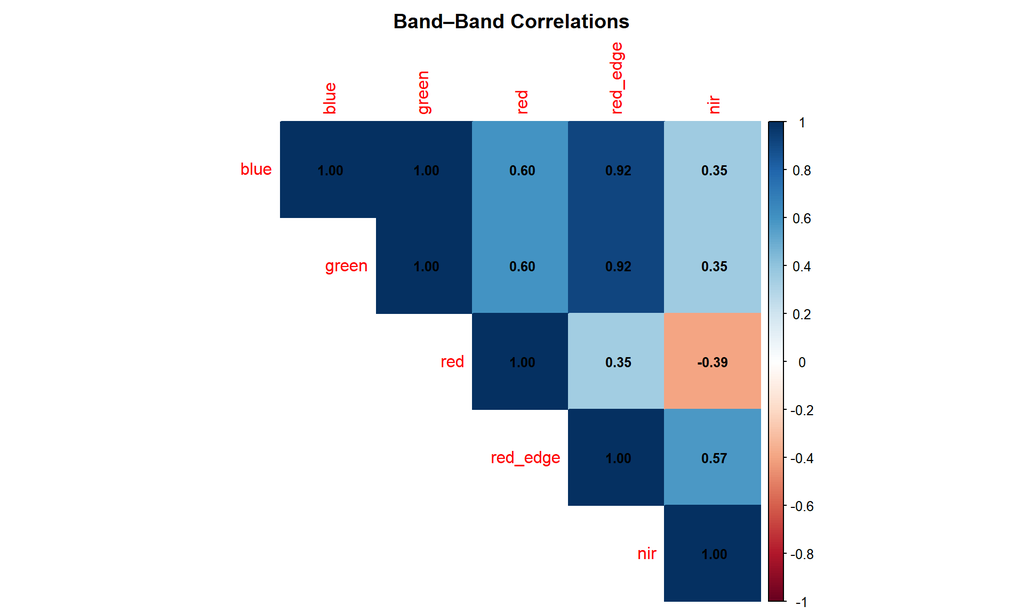

Correlations among raw spectral bands

```r
# ── Visual EDA: band-band and band-VI correlations ─────────────────────────
cor_bands <- cor(model_data[, BAND_NAMES], use = "pairwise.complete.obs")
corrplot(cor_bands, method = "color", type = "upper",
         addCoef.col = "black", number.cex = 0.8,
         title = "Band–Band Correlations", mar = c(0,0,2,0))
```

# 4 MCG25 Diagnostic Analysis

MCG25 (timepoint 12) uses a late-season flight that produces an inverted spectral–yield relationship relative to the other four environments. This section documents the spectral and agronomic characteristics of MCG25 that make it a challenging environment for cross-environment prediction. MCG25 is included in model training; the LOEO fold holding out MCG25 will reveal how well each method generalises to an inverted-relationship environment.

```r
# ── Timepoint context: how late is MCG25_TP12 relative to the other groups? ─
tp_context <- model_data_raw_orig %>%
  distinct(Env, Timepoint, group) %>%
  arrange(Timepoint)

tp_context %>%
  kable(col.names = c("Environment", "Timepoint", "Group"),
        caption = "Selected Timepoint × Environment groups — MCG25 uses a much later flight") %>%
  kable_styling(bootstrap_options = c("striped","hover","condensed"), full_width = FALSE)
```

Selected Timepoint × Environment groups — MCG25 uses a much later flight

| Environment | Timepoint | Group |
| --- | --- | --- |
| KET21 | 4 | KET21_TP4 |
| MCG23 | 5 | MCG23_TP5 |
| SNY22 | 6 | SNY22_TP6 |
| HELF24 | 7 | HELF24_TP7 |
| MCG25 | 12 | MCG25_TP12 |

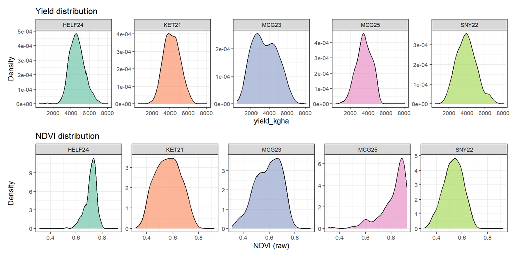

Yield and NDVI distributions per environment

```r
p_yield <- model_data_raw_orig %>%
  filter(!is.na(.data[[trait_cols[1]]])) %>%
  ggplot(aes(x = .data[[trait_cols[1]]], fill = Env)) +
  geom_density(alpha = 0.65) +
  facet_wrap(~Env, ncol = 5, scales = "free_y") +
  scale_fill_brewer(palette = "Set2") +
  labs(x = trait_cols[1], y = "Density", title = "Yield distribution") +
  theme_bw(base_size = 10) + theme(legend.position = "none")

p_ndvi <- model_data_raw_orig %>%
  ggplot(aes(x = NDVI_raw, fill = Env)) +
  geom_density(alpha = 0.65) +
  facet_wrap(~Env, ncol = 5, scales = "free_y") +
  scale_fill_brewer(palette = "Set2") +
  labs(x = "NDVI (raw)", y = "Density", title = "NDVI distribution") +
  theme_bw(base_size = 10) + theme(legend.position = "none")

p_yield / p_ndvi
```

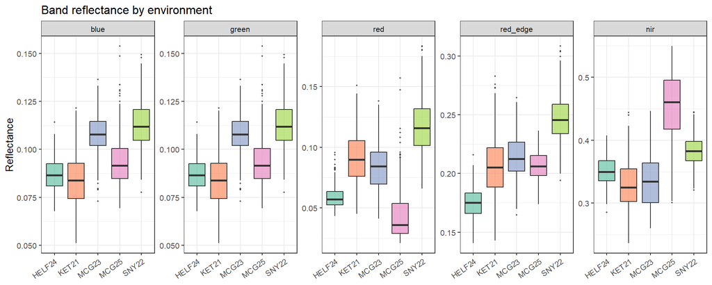

Raw band reflectance distributions by environment — MCG25 at TP12 may occupy a different spectral range

```r
model_data_raw_orig %>%
  select(Env, all_of(BAND_NAMES)) %>%
  pivot_longer(all_of(BAND_NAMES), names_to = "band", values_to = "value") %>%
  mutate(band = factor(band, levels = BAND_NAMES)) %>%
  ggplot(aes(x = Env, y = value, fill = Env)) +
  geom_boxplot(outlier.size = 0.3, alpha = 0.7) +
  facet_wrap(~band, scales = "free_y", nrow = 1) +
  scale_fill_brewer(palette = "Set2") +
  labs(x = NULL, y = "Reflectance", title = "Band reflectance by environment") +
  theme_bw(base_size = 10) +
  theme(axis.text.x = element_text(angle = 35, hjust = 1),
        legend.position = "none")
```

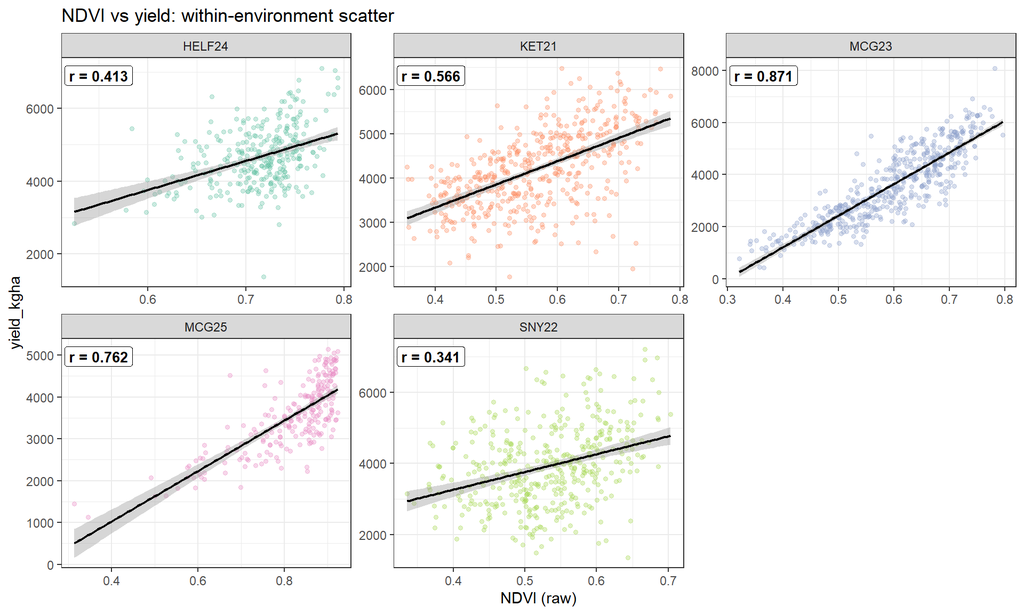

NDVI vs yield within each environment — correlation and regression line

```r
trait_diag <- trait_cols[1]

cors_ndvi <- model_data_raw_orig %>%
  filter(!is.na(.data[[trait_diag]]), !is.na(NDVI_raw)) %>%
  group_by(Env) %>%
  summarise(r     = cor(NDVI_raw, .data[[trait_diag]], use = "complete.obs"),
            label = paste0("r = ", round(r, 3)),
            .groups = "drop")

model_data_raw_orig %>%
  filter(!is.na(.data[[trait_diag]]), !is.na(NDVI_raw)) %>%
  ggplot(aes(x = NDVI_raw, y = .data[[trait_diag]], colour = Env)) +
  geom_point(alpha = 0.35, size = 1.2) +
  geom_smooth(method = "lm", se = TRUE, colour = "black", linewidth = 0.8) +
  geom_label(data = cors_ndvi,
             aes(x = -Inf, y = Inf, label = label),
             hjust = -0.05, vjust = 1.4,
             inherit.aes = FALSE, size = 3.5, fontface = "bold",
             fill = "white", label.size = 0.2) +
  facet_wrap(~Env, ncol = 3, scales = "free") +
  scale_colour_brewer(palette = "Set2") +
  labs(x = "NDVI (raw)", y = trait_diag,
       title = "NDVI vs yield: within-environment scatter") +
  theme_bw(base_size = 11) +
  theme(legend.position = "none")
```

```r
# ── Within-environment Pearson r for every band and NDVI vs trait ──────────
trait_diag <- trait_cols[1]

band_yield_cors <- model_data_raw_orig %>%
  filter(!is.na(.data[[trait_diag]])) %>%
  group_by(Env) %>%
  summarise(
    across(all_of(c(BAND_NAMES, "NDVI_raw")),
           ~ round(cor(., .data[[trait_diag]], use = "complete.obs"), 3)),
    n_obs = sum(!is.na(.data[[trait_diag]])),
    .groups = "drop"
  )

band_yield_cors %>%
  kable(caption = paste("Within-environment Pearson r: each band and NDVI vs", trait_diag)) %>%
  kable_styling(bootstrap_options = c("striped","hover","condensed"), full_width = FALSE)
```

Within-environment Pearson r: each band and NDVI vs yield_kgha

| Env | blue | green | red | red_edge | nir | NDVI_raw | n_obs |
| --- | --- | --- | --- | --- | --- | --- | --- |
| HELF24 | 0.114 | 0.114 | -0.259 | 0.168 | 0.514 | 0.413 | 312 |
| KET21 | 0.184 | 0.184 | -0.416 | 0.325 | 0.552 | 0.566 | 466 |
| MCG23 | 0.030 | 0.030 | -0.779 | 0.530 | 0.890 | 0.871 | 504 |
| MCG25 | -0.757 | -0.757 | -0.756 | -0.600 | 0.777 | 0.762 | 232 |
| SNY22 | -0.213 | -0.213 | -0.380 | 0.000 | 0.008 | 0.341 | 424 |

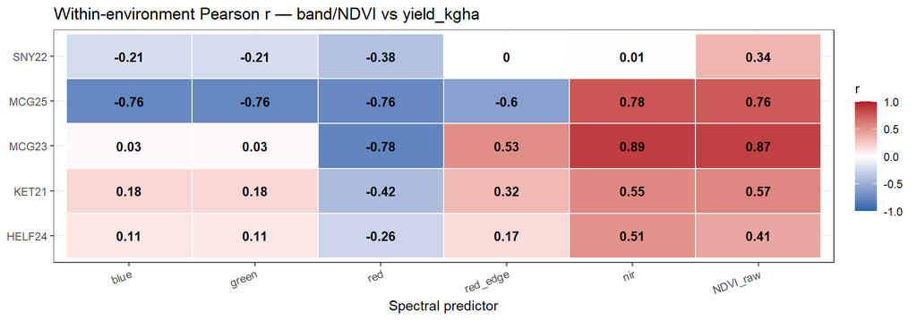

Heatmap of within-environment band–yield correlations

```r
band_yield_cors %>%
  select(Env, all_of(BAND_NAMES), NDVI_raw) %>%
  pivot_longer(-Env, names_to = "band", values_to = "r") %>%
  mutate(band = factor(band, levels = c(BAND_NAMES, "NDVI_raw"))) %>%
  ggplot(aes(x = band, y = Env, fill = r)) +
  geom_tile(colour = "white", linewidth = 0.5) +
  geom_text(aes(label = round(r, 2)), size = 3.5, fontface = "bold") +
  scale_fill_gradient2(low = "#2166ac", mid = "white", high = "#b2182b",
                       midpoint = 0, limits = c(-1, 1)) +
  labs(x = "Spectral predictor", y = NULL,
       title = paste("Within-environment Pearson r — band/NDVI vs", trait_diag),
       fill = "r") +
  theme_bw(base_size = 11) +
  theme(axis.text.x = element_text(angle = 20, hjust = 1))
```

```r
# ── Variance partitioning: η² (between-env SS / total SS) per band ────────
# High η² means most spectral variance is between environments (not genotypes).
# If MCG25 is spectrally extreme, it will dominate the between-env component.
vp <- model_data_raw_orig %>%
  select(Env, all_of(BAND_NAMES), NDVI_raw, all_of(trait_cols[1])) %>%
  pivot_longer(-Env, names_to = "variable", values_to = "value") %>%
  filter(!is.na(value)) %>%
  group_by(variable) %>%
  mutate(grand_mean = mean(value)) %>%
  group_by(variable, Env) %>%
  mutate(env_mean = mean(value)) %>%
  ungroup() %>%
  group_by(variable) %>%
  summarise(
    SS_total   = sum((value - grand_mean)^2),
    SS_between = sum((env_mean - grand_mean)^2),
    eta2       = round(SS_between / SS_total, 3),
    .groups = "drop"
  ) %>%
  arrange(desc(eta2))

vp %>%
  kable(col.names = c("Variable", "SS total", "SS between-env", "η² (between-env)"),
        digits = c(0, 0, 0, 3),
        caption = "Variance partitioning: proportion of total variance attributable to environment") %>%
  kable_styling(bootstrap_options = c("striped","hover","condensed"), full_width = FALSE)
```

Variance partitioning: proportion of total variance attributable to environment

| Variable | SS total | SS between-env | η² (between-env) |
| --- | --- | --- | --- |
| red | 2 | 1 | 0.602 |
| red_edge | 2 | 1 | 0.586 |
| nir | 6 | 3 | 0.555 |
| NDVI_raw | 31 | 17 | 0.534 |
| blue | 1 | 0 | 0.531 |
| green | 1 | 0 | 0.531 |
| yield_kgha | 2491057787 | 299467714 | 0.120 |

# 5 Approach 3: Supervised DNN with Feature Extraction

The network has two components trained **within each Timepoint × Environment group**:

1. **Band Encoder** — three fully-connected layers (n_bands → 16 → 8 → 1). The single output neuron is the *Synthetic VI* — no activation, so it spans the full real line.
2. **Prediction Head** — maps the scalar Synthetic VI through one hidden layer to the trait prediction.

The prediction head receives the Synthetic VI concatenated with a learned **environment embedding** so that the VI→trait mapping can shift per trial, while the encoder (VI formula) remains shared across environments. For unseen environments in LOEO, the mean embedding of the training environments is used as a proxy.

```r
# ══════════════════════════════════════════════════════════════════════════
# Band Encoder: n_bands → 16 → 8 → 1 (Synthetic VI bottleneck)
# ══════════════════════════════════════════════════════════════════════════
BandEncoder <- nn_module(
  classname = "BandEncoder",
  initialize = function(n_bands = 5, h1 = 16, h2 = 8) {
    self$fc1  <- nn_linear(n_bands, h1)
    self$fc2  <- nn_linear(h1, h2)
    self$fc3  <- nn_linear(h2, 1)      # bottleneck = Synthetic VI (linear out)
    self$drop <- nn_dropout(0.1)
  },
  forward = function(x) {
    x <- x %>% self$fc1() %>% nnf_relu() %>% self$drop()
    x <- x %>% self$fc2() %>% nnf_relu() %>% self$drop()
    self$fc3(x)
  }
)

# ══════════════════════════════════════════════════════════════════════════
# Full predictor: encoder → Synthetic VI → prediction head → trait
# ══════════════════════════════════════════════════════════════════════════
SyntheticVIModel <- nn_module(
  classname = "SyntheticVIModel",
  initialize = function(n_bands = 5, n_envs = 5, d_embed = 4L, pred_h = 8L) {
    self$encoder  <- BandEncoder(n_bands)
    self$env_emb  <- nn_embedding(n_envs, d_embed)     # one vector per environment
    self$pred_fc1 <- nn_linear(1L + d_embed, pred_h)   # [SynVI | env_embed] → hidden
    self$pred_fc2 <- nn_linear(pred_h, 1L)
    self$drop     <- nn_dropout(0.1)
  },
  forward = function(bands, env_idx = NULL, env_vec = NULL) {
    vi <- self$encoder(bands)                           # (N, 1)
    ev <- if (!is.null(env_idx)) {
      self$env_emb(env_idx)                             # (N, d_embed) — known env
    } else {
      env_vec$expand(c(vi$size(1), -1L))                # broadcast mean embed for unseen env
    }
    torch_cat(list(vi, ev), dim = 2) %>%
      self$pred_fc1() %>% nnf_relu() %>% self$drop() %>%
      self$pred_fc2()
  },
  get_synthetic_vi = function(bands) {
    self$encoder(bands)
  }
)

cat("Model architecture defined.\n")
```

```
## Model architecture defined.
```

```r
cat("  Encoder:       n_bands → 16 → 8 → 1 (Synthetic VI)\n")
```

```
##   Encoder:       n_bands → 16 → 8 → 1 (Synthetic VI)
```

```r
cat("  Env embedding: n_envs × d_embed = 4\n")
```

```
##   Env embedding: n_envs × d_embed = 4
```

```r
cat("  Predictor:     (1 + 4) → 8 → 1 (trait)\n")
```

```
##   Predictor:     (1 + 4) → 8 → 1 (trait)
```

```r
# ══════════════════════════════════════════════════════════════════════════
# Option 3: Full DNN (no bottleneck) — n_bands → 16 → 8 || env_embed → 8 → 1
# Removes the single-neuron bottleneck so the full 8-dimensional spectral
# representation is passed to the prediction head.
# ══════════════════════════════════════════════════════════════════════════
FullDNNModel <- nn_module(
  classname = "FullDNNModel",
  initialize = function(n_bands = 5, n_envs = 5, d_embed = 4L,
                        h1 = 16L, h2 = 8L, pred_h = 8L) {
    self$fc1      <- nn_linear(n_bands, h1)
    self$fc2      <- nn_linear(h1, h2)
    self$env_emb  <- nn_embedding(n_envs, d_embed)
    self$pred_fc1 <- nn_linear(h2 + d_embed, pred_h)
    self$pred_fc2 <- nn_linear(pred_h, 1L)
    self$drop     <- nn_dropout(0.1)
  },
  forward = function(bands, env_idx = NULL, env_vec = NULL) {
    x <- bands %>% self$fc1() %>% nnf_relu() %>% self$drop()
    x <- x %>% self$fc2() %>% nnf_relu() %>% self$drop()
    ev <- if (!is.null(env_idx)) {
      self$env_emb(env_idx)
    } else {
      env_vec$expand(c(x$size(1), -1L))
    }
    torch_cat(list(x, ev), dim = 2) %>%
      self$pred_fc1() %>% nnf_relu() %>% self$drop() %>%
      self$pred_fc2()
  }
)

cat("FullDNNModel (no bottleneck) defined.\n")
```

```
## FullDNNModel (no bottleneck) defined.
```

```r
cat("  Band encoder:  n_bands → 16 → 8\n")
```

```
##   Band encoder:  n_bands → 16 → 8
```

```r
cat("  Predictor:     (8 + 4) → 8 → 1 (trait)\n")
```

```
##   Predictor:     (8 + 4) → 8 → 1 (trait)
```

# 6 Training

Two CV scenarios are run in parallel:

- **LOEO**: holds out one environment at a time, trains on the other four.
- **Within-env 5-fold CV**: within each environment, GIDs are assigned to 5 folds; the model trains on 4 folds and predicts the 5th.

In both, the band scaler (0–1 min–max) and trait scaler (z-score) are fit on training data only and applied to the test fold — `model_data_raw` (unscaled) is passed to the CV functions so scaling is done internally.

After CV, a final model trained on all data is used to extract the **Synthetic VI formula**.

```r
# ── Helper: build band + label tensors from a pre-scaled data frame ────────
make_tensors <- function(df, trait) {
  df_sub <- df[!is.na(df[[trait]]), ]
  list(
    bands = torch_tensor(as.matrix(df_sub[, BAND_NAMES, drop = FALSE]),
                         dtype = torch_float()),
    y     = torch_tensor(df_sub[[trait]], dtype = torch_float())$unsqueeze(2)
  )
}

# ── Scale df using stats from train_df; return scaled df + back-transform params
scale_from_train <- function(df, train_df, trait) {
  band_sc  <- map(BAND_NAMES, function(b)
    list(mn = min(train_df[[b]], na.rm = TRUE),
         mx = max(train_df[[b]], na.rm = TRUE))) %>% set_names(BAND_NAMES)
  trait_mn <- mean(train_df[[trait]], na.rm = TRUE)
  trait_sd <- sd(train_df[[trait]],   na.rm = TRUE)
  for (b in BAND_NAMES) {
    sc <- band_sc[[b]]
    df[[b]] <- (df[[b]] - sc$mn) / (sc$mx - sc$mn + 1e-8)
  }
  df[[trait]] <- (df[[trait]] - trait_mn) / (trait_sd + 1e-8)
  list(df = df, trait_mn = trait_mn, trait_sd = trait_sd)
}

# ── Core training loop ─────────────────────────────────────────────────────
train_model <- function(train_df, trait, env_levels,
                        epochs = 300, lr = 3e-3, batch_size = 64,
                        seed = NULL, verbose = FALSE) {
  if (!is.null(seed)) torch_manual_seed(seed)
  df_sub  <- train_df[!is.na(train_df[[trait]]), ]
  tensors <- make_tensors(train_df, trait)
  n       <- tensors$bands$size(1)
  if (n < 10) return(NULL)

  # Environment indices (1-based, as required by torch nn_embedding in R)
  env_idx <- torch_tensor(
    match(as.character(df_sub$Env), env_levels),
    dtype = torch_long()
  )

  n_envs <- length(env_levels)
  model  <- SyntheticVIModel(n_bands = length(BAND_NAMES),
                              n_envs = n_envs, d_embed = 4L, pred_h = 8L)
  opt    <- optim_adam(model$parameters, lr = lr, weight_decay = 1e-4)
  sched  <- lr_step(opt, step_size = 100, gamma = 0.5)

  model$train()
  for (ep in seq_len(epochs)) {
    idx <- sample(n)
    for (i in seq(1, n, by = batch_size)) {
      bi <- idx[i:min(i + batch_size - 1, n)]
      opt$zero_grad()
      pred <- model(tensors$bands[bi, , drop = FALSE],
                    env_idx = env_idx[bi])
      loss <- nnf_mse_loss(pred, tensors$y[bi, , drop = FALSE])
      loss$backward()
      nn_utils_clip_grad_norm_(model$parameters, 1.0)
      opt$step()
    }
    sched$step()
    if (verbose && ep %% 100 == 0)
      cat(sprintf("  ep %d | loss %.4f\n", ep, loss$item()))
  }
  model$eval()
  model
}

# ── LOEO: Leave-One-Environment-Out CV ────────────────────────────────────
# Takes raw (unscaled) data. Scaler fit on training environments only.
# For the unseen held-out environment, the mean embedding of the 4 training
# environments is used as a proxy in the prediction head.
loeo_cv <- function(data_raw, trait, env_levels, n_reps = 3,
                    epochs = 300, lr = 3e-3, batch_size = 64) {
  envs <- sort(unique(as.character(data_raw$Env)))
  map_dfr(envs, function(held_env) {
    train_raw <- data_raw %>% filter(Env != held_env, !is.na(.data[[trait]]))
    test_raw  <- data_raw %>% filter(Env == held_env,  !is.na(.data[[trait]]))
    if (nrow(train_raw) < 10 || nrow(test_raw) < 2) return(NULL)

    sc_out   <- scale_from_train(train_raw, train_raw, trait)
    train_sc <- sc_out$df
    trait_mn <- sc_out$trait_mn
    trait_sd <- sc_out$trait_sd
    test_sc  <- scale_from_train(test_raw, train_raw, trait)$df

    # Indices (1-based) of the 4 training environments
    train_env_idx <- torch_tensor(
      match(sort(unique(as.character(train_raw$Env))), env_levels),
      dtype = torch_long()
    )

    map_dfr(seq_len(n_reps), function(rep_i) {
      model <- tryCatch(
        train_model(train_sc, trait, env_levels = env_levels,
                    epochs = epochs, lr = lr,
                    batch_size = batch_size, seed = rep_i * 100L),
        error = function(e) { message(held_env, " rep", rep_i, ": ", e$message); NULL }
      )
      if (is.null(model)) return(NULL)

      # Mean embedding of training envs → proxy for unseen held-out environment
      mean_env_vec <- with_no_grad({
        model$env_emb(train_env_idx)$mean(dim = 1, keepdim = TRUE)
      })

      te_ten <- make_tensors(test_sc, trait)
      with_no_grad({
        pred_z <- model(te_ten$bands, env_vec = mean_env_vec)$squeeze()$to(device = "cpu")
      })
      pred <- as.numeric(pred_z) * trait_sd + trait_mn
      obs  <- as.numeric(te_ten$y$squeeze()) * trait_sd + trait_mn
      tibble(held_env = held_env, rep = rep_i, n_test = length(obs),
             r    = cor(pred, obs, use = "complete.obs"),
             rmse = sqrt(mean((pred - obs)^2, na.rm = TRUE)))
    })
  })
}

# ── Within-environment 5-fold CV (split by GID) ───────────────────────────
# Takes raw (unscaled) data. GIDs assigned to folds; scaler fit on train GIDs.
# The correct environment index is known for both train and test, so the
# learned embedding is used directly (no mean-proxy needed).
within_env_cv <- function(data_raw, trait, env_levels, n_folds = 5, n_reps = 3,
                          epochs = 300, lr = 3e-3, batch_size = 64) {
  envs <- sort(unique(as.character(data_raw$Env)))
  map_dfr(envs, function(env_i) {
    env_df    <- data_raw %>% filter(Env == env_i, !is.na(.data[[trait]]))
    gids      <- unique(env_df$GID)
    env_i_idx <- match(env_i, env_levels)   # 1-based index for this env (torch R convention)
    if (length(gids) < n_folds) {
      message("Env ", env_i, ": ", length(gids), " GIDs < n_folds — skipping")
      return(NULL)
    }
    map_dfr(seq_len(n_reps), function(rep_i) {
      set.seed(rep_i * 77L)
      shuffled <- sample(gids)
      fold_id  <- rep(seq_len(n_folds), length.out = length(shuffled))
      gid_fold <- tibble(GID = shuffled, fold = fold_id)

      map_dfr(seq_len(n_folds), function(f) {
        test_gids   <- gid_fold$GID[gid_fold$fold == f]
        train_raw_f <- env_df %>% filter(!GID %in% test_gids)
        test_raw_f  <- env_df %>% filter( GID %in% test_gids)
        if (nrow(train_raw_f) < 10 || nrow(test_raw_f) < 2) return(NULL)
```

```r
        sc_out   <- scale_from_train(train_raw_f, train_raw_f, trait)
        train_sc <- sc_out$df
        trait_mn <- sc_out$trait_mn
        trait_sd <- sc_out$trait_sd
        test_sc  <- scale_from_train(test_raw_f, train_raw_f, trait)$df

        model <- tryCatch(
          train_model(train_sc, trait, env_levels = env_levels,
                      epochs = epochs, lr = lr,
                      batch_size = batch_size, seed = rep_i * 100L + f),
          error = function(e) NULL
        )
        if (is.null(model)) return(NULL)
        te_ten    <- make_tensors(test_sc, trait)
        te_env_idx <- torch_tensor(
          rep(env_i_idx, te_ten$bands$size(1)),
          dtype = torch_long()
        )
        with_no_grad({
          pred_z <- model(te_ten$bands,
                          env_idx = te_env_idx)$squeeze()$to(device = "cpu")
        })
        pred <- as.numeric(pred_z) * trait_sd + trait_mn
        obs  <- as.numeric(te_ten$y$squeeze()) * trait_sd + trait_mn
        tibble(Env = env_i, fold = f, rep = rep_i, n_test = length(obs),
               r    = cor(pred, obs, use = "complete.obs"),
               rmse = sqrt(mean((pred - obs)^2, na.rm = TRUE)))
      })
    })
  })
}

# ── Linear-model LOEO CV (for NDVI baseline) ─────────────────────────────
linreg_loeo_cv <- function(data_raw, predictor, trait) {
  envs <- sort(unique(as.character(data_raw$Env)))
  map_dfr(envs, function(held_env) {
    tr <- data_raw %>% filter(Env != held_env,
                              !is.na(.data[[predictor]]), !is.na(.data[[trait]]))
    te <- data_raw %>% filter(Env == held_env,
                              !is.na(.data[[predictor]]), !is.na(.data[[trait]]))
    if (nrow(tr) < 10 || nrow(te) < 2) return(NULL)
    fit  <- lm(as.formula(paste(trait, "~", predictor)), data = tr)
    pred <- predict(fit, newdata = te)
    obs  <- te[[trait]]
    tibble(held_env = held_env, n_test = nrow(te),
           r    = cor(pred, obs, use = "complete.obs"),
           rmse = sqrt(mean((pred - obs)^2, na.rm = TRUE)))
  })
}

# ── Linear-model within-env 5-fold CV by GID (for NDVI baseline) ──────────
linreg_wenv_cv <- function(data_raw, predictor, trait,
                           n_folds = 5, n_reps = 3) {
  envs <- sort(unique(as.character(data_raw$Env)))
  map_dfr(envs, function(env_i) {
    env_df <- data_raw %>% filter(Env == env_i,
                                  !is.na(.data[[predictor]]), !is.na(.data[[trait]]))
    gids <- unique(env_df$GID)
    if (length(gids) < n_folds) return(NULL)
    map_dfr(seq_len(n_reps), function(rep_i) {
      set.seed(rep_i * 77L)
      shuffled <- sample(gids)
      fold_id  <- rep(seq_len(n_folds), length.out = length(shuffled))
      gid_fold <- tibble(GID = shuffled, fold = fold_id)
      map_dfr(seq_len(n_folds), function(f) {
        test_gids <- gid_fold$GID[gid_fold$fold == f]
        tr <- env_df %>% filter(!GID %in% test_gids)
        te <- env_df %>% filter( GID %in% test_gids)
        if (nrow(tr) < 5 || nrow(te) < 2) return(NULL)
        fit  <- lm(as.formula(paste(trait, "~", predictor)), data = tr)
        pred <- predict(fit, newdata = te)
        obs  <- te[[trait]]
        tibble(Env = env_i, fold = f, rep = rep_i, n_test = nrow(te),
               r    = cor(pred, obs, use = "complete.obs"),
               rmse = sqrt(mean((pred - obs)^2, na.rm = TRUE)))
      })
    })
  })
}

# ── Helper: extract Synthetic VI values from a frozen encoder ─────────────
extract_synvi <- function(model, df) {
  if (nrow(df) == 0) return(numeric(0))
  bands_t <- torch_tensor(as.matrix(df[, BAND_NAMES, drop = FALSE]),
                          dtype = torch_float())
  with_no_grad({
    vi <- model$get_synthetic_vi(bands_t)$squeeze()
    if (vi$dim() == 0L) vi <- vi$unsqueeze(1L)
    as.numeric(vi$to(device = "cpu"))
  })
}

# ── Variant B: pre-train on 4 envs → freeze encoder → fine-tune head ───────
# Pre-trains on the other 4 environments, then for each fold within the target
# environment freezes the encoder and fine-tunes only the prediction head and
# environment embeddings on the adaptation (train) GIDs, then predicts the test GIDs.
adapt_finetune_cv <- function(data_raw, trait, env_levels,
                               n_folds        = 5,   n_reps         = 3,
                               pretrain_epochs = 300, pretrain_lr    = 3e-3,
                               finetune_epochs = 50,  finetune_lr    = 1e-3,
                               batch_size      = 64) {
  envs <- sort(unique(as.character(data_raw$Env)))

  map_dfr(envs, function(target_env) {
    train_4env <- data_raw %>% filter(Env != target_env, !is.na(.data[[trait]]))
    target_df  <- data_raw %>% filter(Env == target_env,  !is.na(.data[[trait]]))
    gids       <- unique(target_df$GID)
    if (nrow(train_4env) < 10 || length(gids) < n_folds) return(NULL)

    # Scaler fit on 4 training environments — applied to adaptation & test folds too
    sc_out   <- scale_from_train(train_4env, train_4env, trait)
    train_sc <- sc_out$df
    trait_mn <- sc_out$trait_mn
    trait_sd <- sc_out$trait_sd

    target_env_i <- match(target_env, env_levels)  # 1-based embedding index

    map_dfr(seq_len(n_reps), function(rep_i) {
      # Step 1: pre-train on 4 environments
      pretrained <- tryCatch(
        train_model(train_sc, trait, env_levels = env_levels,
                    epochs = pretrain_epochs, lr = pretrain_lr,
                    batch_size = batch_size, seed = rep_i * 100L),
        error = function(e) { message(target_env, " rep", rep_i, ": ", e$message); NULL }
      )
      if (is.null(pretrained)) return(NULL)

      pretrained_state <- pretrained$state_dict()  # snapshot before any fine-tuning

      # K-fold CV within target environment (by GID)
      set.seed(rep_i * 77L)
      shuffled <- sample(gids)
      fold_id  <- rep(seq_len(n_folds), length.out = length(shuffled))
      gid_fold <- tibble(GID = shuffled, fold = fold_id)

      map_dfr(seq_len(n_folds), function(f) {
        test_gids  <- gid_fold$GID[gid_fold$fold == f]
        adapt_gids <- gids[!gids %in% test_gids]
        adapt_df   <- target_df %>% filter(GID %in% adapt_gids)
        test_df    <- target_df %>% filter(GID %in% test_gids)
        if (nrow(adapt_df) < 5 || nrow(test_df) < 2) return(NULL)
```

```r
        # Scale with train_4env stats (bands 0-1, trait z-scored for head loss)
        adapt_sc <- scale_from_train(adapt_df, train_4env, trait)$df
        test_sc  <- scale_from_train(test_df,  train_4env, trait)$df

        # Fresh model initialised from pre-trained weights (clean copy per fold)
        model_ft <- SyntheticVIModel(n_bands = length(BAND_NAMES),
                                      n_envs  = length(env_levels),
                                      d_embed = 4L, pred_h = 8L)
        model_ft$load_state_dict(pretrained_state)

        # Freeze encoder — gradients disabled for all BandEncoder parameters
        for (p in model_ft$encoder$parameters) p$requires_grad_(FALSE)

        # Collect only trainable parameters (head + embeddings)
        trainable <- list(
          model_ft$env_emb$weight,
          model_ft$pred_fc1$weight, model_ft$pred_fc1$bias,
          model_ft$pred_fc2$weight, model_ft$pred_fc2$bias
        )
        opt_ft <- optim_adam(trainable, lr = finetune_lr, weight_decay = 1e-4)

        adapt_ten     <- make_tensors(adapt_sc, trait)
        n_adapt       <- adapt_ten$bands$size(1)
        adapt_env_idx <- torch_tensor(rep(target_env_i, n_adapt), dtype = torch_long())

        # Step 2: fine-tune head on adaptation fold
        model_ft$train()
        for (ep in seq_len(finetune_epochs)) {
          idx_s <- sample(n_adapt)
          for (i in seq(1, n_adapt, by = batch_size)) {
            bi <- idx_s[i:min(i + batch_size - 1, n_adapt)]
            # Recreate env index tensor directly to avoid 0D scalar from single-element indexing
            ei <- torch_tensor(rep(target_env_i, length(bi)), dtype = torch_long())
            opt_ft$zero_grad()
            pred_ft <- model_ft(adapt_ten$bands[bi, , drop = FALSE], env_idx = ei)
            loss <- nnf_mse_loss(pred_ft, adapt_ten$y[bi, , drop = FALSE])
            loss$backward()
            nn_utils_clip_grad_norm_(trainable, 1.0)
            opt_ft$step()
          }
        }
        model_ft$eval()

        # Step 3: predict test fold
        test_ten   <- make_tensors(test_sc, trait)
        te_env_idx <- torch_tensor(
          rep(target_env_i, test_ten$bands$size(1)), dtype = torch_long()
        )
        with_no_grad({
          pred_z <- model_ft(test_ten$bands, env_idx = te_env_idx)$squeeze()$to(device = "cpu")
        })
        pred <- as.numeric(pred_z) * trait_sd + trait_mn
        obs  <- as.numeric(test_ten$y$squeeze()) * trait_sd + trait_mn

        tibble(Env = target_env, fold = f, rep = rep_i, n_test = length(obs),
               r    = cor(pred, obs, use = "complete.obs"),
               rmse = sqrt(mean((pred - obs)^2, na.rm = TRUE)))
      })
    })
  })
}

# ── Variant C: pre-train on 4 envs → freeze encoder → linear regression ────
# Pre-trains on the other 4 environments, extracts the Synthetic VI from the
# frozen encoder, then fits a simple OLS (trait ~ SynVI) on the adaptation GIDs
# and predicts the test GIDs. No gradient updates to the DNN in this stage.
adapt_lm_cv <- function(data_raw, trait, env_levels,
                         n_folds        = 5, n_reps      = 3,
                         pretrain_epochs = 300, pretrain_lr = 3e-3,
                         batch_size      = 64) {
  envs <- sort(unique(as.character(data_raw$Env)))

  map_dfr(envs, function(target_env) {
    train_4env <- data_raw %>% filter(Env != target_env, !is.na(.data[[trait]]))
    target_df  <- data_raw %>% filter(Env == target_env,  !is.na(.data[[trait]]))
    gids       <- unique(target_df$GID)
    if (nrow(train_4env) < 10 || length(gids) < n_folds) return(NULL)

    sc_out   <- scale_from_train(train_4env, train_4env, trait)
    train_sc <- sc_out$df

    map_dfr(seq_len(n_reps), function(rep_i) {
      # Step 1: pre-train encoder on 4 environments
      pretrained <- tryCatch(
        train_model(train_sc, trait, env_levels = env_levels,
                    epochs = pretrain_epochs, lr = pretrain_lr,
                    batch_size = batch_size, seed = rep_i * 100L),
        error = function(e) { message(target_env, " rep", rep_i, ": ", e$message); NULL }
      )
      if (is.null(pretrained)) return(NULL)
      pretrained$eval()

      # K-fold CV within target environment (by GID)
      set.seed(rep_i * 77L)
      shuffled <- sample(gids)
      fold_id  <- rep(seq_len(n_folds), length.out = length(shuffled))
      gid_fold <- tibble(GID = shuffled, fold = fold_id)

      map_dfr(seq_len(n_folds), function(f) {
        test_gids  <- gid_fold$GID[gid_fold$fold == f]
        adapt_gids <- gids[!gids %in% test_gids]
        adapt_df   <- target_df %>% filter(GID %in% adapt_gids)
        test_df    <- target_df %>% filter(GID %in% test_gids)
        if (nrow(adapt_df) < 5 || nrow(test_df) < 2) return(NULL)

        # Scale bands using train_4env scaler (encoder trained on this scale)
        adapt_sc_bands <- scale_from_train(adapt_df, train_4env, trait)$df
        test_sc_bands  <- scale_from_train(test_df,  train_4env, trait)$df

        # Step 2: extract SynVI from frozen encoder (no gradient updates)
        synvi_adapt <- extract_synvi(pretrained, adapt_sc_bands)
        synvi_test  <- extract_synvi(pretrained, test_sc_bands)

        # Step 3: fit OLS on original-scale trait ~ SynVI, predict test
        adapt_y <- adapt_df[[trait]]
        test_y  <- test_df[[trait]]

        lm_fit <- lm(y ~ synvi, data.frame(y = adapt_y, synvi = synvi_adapt))
        pred   <- predict(lm_fit, data.frame(synvi = synvi_test))

        tibble(Env = target_env, fold = f, rep = rep_i, n_test = length(test_y),
               r    = cor(pred, test_y, use = "complete.obs"),
               rmse = sqrt(mean((pred - test_y)^2, na.rm = TRUE)))
      })
    })
  })
}
```

```r
# ── Train FullDNNModel ─────────────────────────────────────────────────────
train_fulldnn <- function(train_df, trait, env_levels,
                           epochs = 300, lr = 3e-3, batch_size = 64,
                           seed = NULL, verbose = FALSE) {
  if (!is.null(seed)) torch_manual_seed(seed)
  df_sub  <- train_df[!is.na(train_df[[trait]]), ]
  tensors <- make_tensors(train_df, trait)
  n       <- tensors$bands$size(1)
  if (n < 10) return(NULL)

  env_idx <- torch_tensor(
    match(as.character(df_sub$Env), env_levels), dtype = torch_long()
  )
  model <- FullDNNModel(n_bands = length(BAND_NAMES), n_envs = length(env_levels),
                         d_embed = 4L, h1 = 16L, h2 = 8L, pred_h = 8L)
  opt   <- optim_adam(model$parameters, lr = lr, weight_decay = 1e-4)
  sched <- lr_step(opt, step_size = 100, gamma = 0.5)

  model$train()
  for (ep in seq_len(epochs)) {
    idx <- sample(n)
    for (i in seq(1, n, by = batch_size)) {
      bi <- idx[i:min(i + batch_size - 1, n)]
      opt$zero_grad()
      pred <- model(tensors$bands[bi, , drop = FALSE], env_idx = env_idx[bi])
      loss <- nnf_mse_loss(pred, tensors$y[bi, , drop = FALSE])
      loss$backward()
      nn_utils_clip_grad_norm_(model$parameters, 1.0)
      opt$step()
    }
    sched$step()
    if (verbose && ep %% 100 == 0)
      cat(sprintf("  ep %d | loss %.4f\n", ep, loss$item()))
  }
  model$eval()
  model
}

# ── LOEO CV for FullDNNModel ───────────────────────────────────────────────
loeo_cv_fulldnn <- function(data_raw, trait, env_levels, n_reps = 3,
                              epochs = 300, lr = 3e-3, batch_size = 64) {
  envs <- sort(unique(as.character(data_raw$Env)))
  map_dfr(envs, function(held_env) {
    train_raw <- data_raw %>% filter(Env != held_env, !is.na(.data[[trait]]))
    test_raw  <- data_raw %>% filter(Env == held_env,  !is.na(.data[[trait]]))
    if (nrow(train_raw) < 10 || nrow(test_raw) < 2) return(NULL)

    sc_out   <- scale_from_train(train_raw, train_raw, trait)
    train_sc <- sc_out$df; trait_mn <- sc_out$trait_mn; trait_sd <- sc_out$trait_sd
    test_sc  <- scale_from_train(test_raw, train_raw, trait)$df

    train_env_idx <- torch_tensor(
      match(sort(unique(as.character(train_raw$Env))), env_levels),
      dtype = torch_long()
    )
    map_dfr(seq_len(n_reps), function(rep_i) {
      model <- tryCatch(
        train_fulldnn(train_sc, trait, env_levels = env_levels,
                      epochs = epochs, lr = lr, batch_size = batch_size,
                      seed = rep_i * 100L),
        error = function(e) { message(held_env, " rep", rep_i, ": ", e$message); NULL }
      )
      if (is.null(model)) return(NULL)
      mean_env_vec <- with_no_grad({
        model$env_emb(train_env_idx)$mean(dim = 1, keepdim = TRUE)
      })
      te_ten <- make_tensors(test_sc, trait)
      with_no_grad({
        pred_z <- model(te_ten$bands, env_vec = mean_env_vec)$squeeze()$to(device = "cpu")
      })
      pred <- as.numeric(pred_z) * trait_sd + trait_mn
      obs  <- as.numeric(te_ten$y$squeeze()) * trait_sd + trait_mn
      tibble(held_env = held_env, rep = rep_i, n_test = length(obs),
             r    = cor(pred, obs, use = "complete.obs"),
             rmse = sqrt(mean((pred - obs)^2, na.rm = TRUE)))
    })
  })
}

# ── Within-env 5-fold CV for FullDNNModel ─────────────────────────────────
within_env_cv_fulldnn <- function(data_raw, trait, env_levels,
                                    n_folds = 5, n_reps = 3,
                                    epochs = 300, lr = 3e-3, batch_size = 64) {
  envs <- sort(unique(as.character(data_raw$Env)))
  map_dfr(envs, function(env_i) {
    env_df    <- data_raw %>% filter(Env == env_i, !is.na(.data[[trait]]))
    gids      <- unique(env_df$GID)
    env_i_idx <- match(env_i, env_levels)
    if (length(gids) < n_folds) {
      message("Env ", env_i, ": ", length(gids), " GIDs < n_folds — skipping")
      return(NULL)
    }
    map_dfr(seq_len(n_reps), function(rep_i) {
      set.seed(rep_i * 77L)
      shuffled <- sample(gids)
      fold_id  <- rep(seq_len(n_folds), length.out = length(shuffled))
      gid_fold <- tibble(GID = shuffled, fold = fold_id)
      map_dfr(seq_len(n_folds), function(f) {
        test_gids   <- gid_fold$GID[gid_fold$fold == f]
        train_raw_f <- env_df %>% filter(!GID %in% test_gids)
        test_raw_f  <- env_df %>% filter( GID %in% test_gids)
        if (nrow(train_raw_f) < 10 || nrow(test_raw_f) < 2) return(NULL)
        sc_out   <- scale_from_train(train_raw_f, train_raw_f, trait)
        train_sc <- sc_out$df; trait_mn <- sc_out$trait_mn; trait_sd <- sc_out$trait_sd
        test_sc  <- scale_from_train(test_raw_f, train_raw_f, trait)$df
        model <- tryCatch(
          train_fulldnn(train_sc, trait, env_levels = env_levels,
                        epochs = epochs, lr = lr, batch_size = batch_size,
                        seed = rep_i * 100L + f),
          error = function(e) NULL
        )
        if (is.null(model)) return(NULL)
        te_ten     <- make_tensors(test_sc, trait)
        te_env_idx <- torch_tensor(rep(env_i_idx, te_ten$bands$size(1)), dtype = torch_long())
        with_no_grad({
          pred_z <- model(te_ten$bands, env_idx = te_env_idx)$squeeze()$to(device = "cpu")
        })
        pred <- as.numeric(pred_z) * trait_sd + trait_mn
        obs  <- as.numeric(te_ten$y$squeeze()) * trait_sd + trait_mn
        tibble(Env = env_i, fold = f, rep = rep_i, n_test = length(obs),
               r    = cor(pred, obs, use = "complete.obs"),
               rmse = sqrt(mean((pred - obs)^2, na.rm = TRUE)))
      })
    })
  })
}
```

```r
# ─────────────────────────────────────────────────────────────────────────────
# Approach 2: Symbolic Regression (LASSO polynomial SR and PySR)
# ─────────────────────────────────────────────────────────────────────────────
# ── Degree-2 polynomial feature matrix from band columns ───────────────────
# Features: 5 linear + 5 squared + 10 pairwise interactions = 20 terms.
# LASSO then selects the sparse subset that predicts the trait.
make_poly_features <- function(df) {
  X       <- as.matrix(df[, BAND_NAMES])
  squared <- X ^ 2
  colnames(squared) <- paste0(BAND_NAMES, "_sq")
  pairs   <- combn(seq_len(ncol(X)), 2, function(idx) X[, idx[1]] * X[, idx[2]])
  colnames(pairs) <- combn(BAND_NAMES, 2, paste, collapse = "x")
  cbind(X, squared, pairs)
}

# ── LASSO polynomial SR — LOEO CV ─────────────────────────────────────────
lasso_poly_loeo_cv <- function(data_raw, trait) {
  envs <- sort(unique(as.character(data_raw$Env)))
  map_dfr(envs, function(held_env) {
    train_raw <- data_raw %>% filter(Env != held_env, !is.na(.data[[trait]]))
    test_raw  <- data_raw %>% filter(Env == held_env,  !is.na(.data[[trait]]))
    if (nrow(train_raw) < 10 || nrow(test_raw) < 2) return(NULL)

    sc_out   <- scale_from_train(train_raw, train_raw, trait)
    train_sc <- sc_out$df; trait_mn <- sc_out$trait_mn; trait_sd <- sc_out$trait_sd
    test_sc  <- scale_from_train(test_raw, train_raw, trait)$df

    X_tr <- make_poly_features(train_sc)
    X_te <- make_poly_features(test_sc)

    set.seed(42)
    fit    <- glmnet::cv.glmnet(X_tr, train_sc[[trait]], alpha = 1, nfolds = 5)
    pred_z <- as.numeric(predict(fit, X_te, s = "lambda.min"))
    pred   <- pred_z * trait_sd + trait_mn
    obs    <- test_raw[[trait]]

    # Non-zero coefficients → readable formula string
    coef_v  <- as.numeric(coef(fit, s = "lambda.min"))
    feat_nm <- c("(Intercept)", colnames(X_tr))
    nz      <- which(coef_v != 0)
    formula_str <- paste(
      sprintf("%+.4f*%s", coef_v[nz], feat_nm[nz]), collapse = " "
    )

    tibble(held_env = held_env, n_test = nrow(test_raw),
           r       = cor(pred, obs, use = "complete.obs"),
           rmse    = sqrt(mean((pred - obs)^2, na.rm = TRUE)),
           n_terms = length(nz) - 1L,
           formula = formula_str)
  })
}

# ── LASSO polynomial SR — Within-env 5-fold CV ────────────────────────────
lasso_poly_wenv_cv <- function(data_raw, trait, n_folds = 5, n_reps = 3) {
  envs <- sort(unique(as.character(data_raw$Env)))
  map_dfr(envs, function(env_i) {
    env_df <- data_raw %>% filter(Env == env_i, !is.na(.data[[trait]]))
    gids   <- unique(env_df$GID)
    if (length(gids) < n_folds) return(NULL)
    map_dfr(seq_len(n_reps), function(rep_i) {
      set.seed(rep_i * 77L)
      shuffled <- sample(gids)
      fold_id  <- rep(seq_len(n_folds), length.out = length(shuffled))
      gid_fold <- tibble(GID = shuffled, fold = fold_id)
      map_dfr(seq_len(n_folds), function(f) {
        test_gids   <- gid_fold$GID[gid_fold$fold == f]
        train_raw_f <- env_df %>% filter(!GID %in% test_gids)
        test_raw_f  <- env_df %>% filter( GID %in% test_gids)
        if (nrow(train_raw_f) < 10 || nrow(test_raw_f) < 2) return(NULL)
        sc_out   <- scale_from_train(train_raw_f, train_raw_f, trait)
        train_sc <- sc_out$df; trait_mn <- sc_out$trait_mn; trait_sd <- sc_out$trait_sd
        test_sc  <- scale_from_train(test_raw_f, train_raw_f, trait)$df
        X_tr <- make_poly_features(train_sc)
        X_te <- make_poly_features(test_sc)
        set.seed(rep_i * 100L + f)
        fit    <- glmnet::cv.glmnet(X_tr, train_sc[[trait]], alpha = 1, nfolds = 5)
        pred_z <- as.numeric(predict(fit, X_te, s = "lambda.min"))
        pred   <- pred_z * trait_sd + trait_mn
        obs    <- test_raw_f[[trait]]
        tibble(Env = env_i, fold = f, rep = rep_i, n_test = length(obs),
               r    = cor(pred, obs, use = "complete.obs"),
               rmse = sqrt(mean((pred - obs)^2, na.rm = TRUE)))
      })
    })
  })
}

# ── PySR via reticulate (requires: pip install pysr) ──────────────────────
# If Python / PySR is not installed the functions return an empty tibble and
# print installation instructions. Set up Python first with:
#   reticulate::install_python()      # if no Python found
#   reticulate::py_install("pysr")    # install PySR into that environment
pysr_loeo_cv <- function(data_raw, trait, niterations = 40L) {
  pysr_ok <- tryCatch({ reticulate::import("pysr"); TRUE }, error = function(e) FALSE)
  if (!pysr_ok) {
    message("PySR not available. Run: reticulate::py_install('pysr') and retry.")
    return(tibble())
  }
  pysr <- reticulate::import("pysr")
  np   <- reticulate::import("numpy")
  envs <- sort(unique(as.character(data_raw$Env)))

  map_dfr(envs, function(held_env) {
    train_raw <- data_raw %>% filter(Env != held_env, !is.na(.data[[trait]]))
    test_raw  <- data_raw %>% filter(Env == held_env,  !is.na(.data[[trait]]))
    if (nrow(train_raw) < 10 || nrow(test_raw) < 2) return(NULL)

    sc_out   <- scale_from_train(train_raw, train_raw, trait)
    train_sc <- sc_out$df; trait_mn <- sc_out$trait_mn; trait_sd <- sc_out$trait_sd
    test_sc  <- scale_from_train(test_raw, train_raw, trait)$df

    X_tr <- np$array(as.matrix(train_sc[, BAND_NAMES]))
    y_tr <- np$array(train_sc[[trait]])
    X_te <- np$array(as.matrix(test_sc[, BAND_NAMES]))

    model_sr <- pysr$PySRRegressor(
      niterations      = niterations,
      binary_operators = list("+", "-", "*", "/"),
      unary_operators  = list("square", "sqrt"),
      maxsize          = 20L,
      verbosity        = 0L,
      random_state     = 42L,
      temp_equation_file = TRUE,
      delete_tempfiles   = TRUE,
      variable_names   = BAND_NAMES
    )
    model_sr$fit(X_tr, y_tr)

    pred_z  <- as.numeric(model_sr$predict(X_te))
    pred    <- pred_z * trait_sd + trait_mn
    obs     <- test_raw[[trait]]
    best_eq <- tryCatch(
      as.character(model_sr$get_best()[["sympy_format"]]),
      error = function(e) "N/A"
    )
    tibble(held_env = held_env, n_test = nrow(test_raw),
           r       = cor(pred, obs, use = "complete.obs"),
           rmse    = sqrt(mean((pred - obs)^2, na.rm = TRUE)),
           formula = best_eq)
  })
}

# ── PySR within-env 5-fold CV ─────────────────────────────────────────────
pysr_wenv_cv <- function(data_raw, trait, n_folds = 5, n_reps = 3,
                          niterations = 20L) {
  pysr_ok <- tryCatch({ reticulate::import("pysr"); TRUE }, error = function(e) FALSE)
  if (!pysr_ok) {
    message("PySR not available. Run: reticulate::py_install('pysr') and retry.")
    return(tibble())
  }
  pysr <- reticulate::import("pysr")
  np   <- reticulate::import("numpy")
  envs <- sort(unique(as.character(data_raw$Env)))

  map_dfr(envs, function(env_i) {
    env_df <- data_raw %>% filter(Env == env_i, !is.na(.data[[trait]]))
    gids   <- unique(env_df$GID)
    if (length(gids) < n_folds) return(NULL)
    map_dfr(seq_len(n_reps), function(rep_i) {
      set.seed(rep_i * 77L)
      shuffled <- sample(gids)
      fold_id  <- rep(seq_len(n_folds), length.out = length(shuffled))
      gid_fold <- tibble(GID = shuffled, fold = fold_id)
      map_dfr(seq_len(n_folds), function(f) {
        test_gids   <- gid_fold$GID[gid_fold$fold == f]
        train_raw_f <- env_df %>% filter(!GID %in% test_gids)
        test_raw_f  <- env_df %>% filter( GID %in% test_gids)
        if (nrow(train_raw_f) < 10 || nrow(test_raw_f) < 2) return(NULL)
        sc_out   <- scale_from_train(train_raw_f, train_raw_f, trait)
        train_sc <- sc_out$df; trait_mn <- sc_out$trait_mn; trait_sd <- sc_out$trait_sd
        test_sc  <- scale_from_train(test_raw_f, train_raw_f, trait)$df
        X_tr <- np$array(as.matrix(train_sc[, BAND_NAMES]))
        y_tr <- np$array(train_sc[[trait]])
        X_te <- np$array(as.matrix(test_sc[, BAND_NAMES]))
        model_sr <- pysr$PySRRegressor(
          niterations      = niterations,
          binary_operators = list("+", "-", "*", "/"),
          unary_operators  = list("square", "sqrt"),
          maxsize          = 15L,
          verbosity        = 0L,
          random_state     = rep_i * 100L + f,
          temp_equation_file = TRUE,
          delete_tempfiles   = TRUE,
          variable_names   = BAND_NAMES
        )
        model_sr$fit(X_tr, y_tr)
        pred_z <- as.numeric(model_sr$predict(X_te))
        pred   <- pred_z * trait_sd + trait_mn
        obs    <- test_raw_f[[trait]]
        tibble(Env = env_i, fold = f, rep = rep_i, n_test = length(obs),
               r    = cor(pred, obs, use = "complete.obs"),
               rmse = sqrt(mean((pred - obs)^2, na.rm = TRUE)))
      })
    })
  })
}
```

```r
# ─────────────────────────────────────────────────────────────────────────────
# Approach 1: L-BFGS Coefficient Optimisation of the Normalised-Difference VI
# ─────────────────────────────────────────────────────────────────────────────
# Generalises NDVI = (NIR - RED)/(NIR + RED) to all 5 bands with learnable
# coefficients.  Numerator weights w_num are unrestricted; denominator weights
# are exp(w_den) > 0 to prevent denominator collapse.  L-BFGS minimises
# -|cor(VI, trait)| on training data.  Initialised at the NDVI solution.
# A simple OLS (trait_z ~ VI) calibrates the linear scale after optimisation.

lbfgs_vi <- function(params, X) {
  n <- ncol(X)
  w_num <- params[seq_len(n)]
  w_den <- exp(params[seq_len(n) + n])
  num   <- drop(X %*% w_num)
  den   <- drop(X %*% w_den)
  num / (den + 1e-8)
}

lbfgs_vi_loeo_cv <- function(data_raw, trait) {
  envs    <- sort(unique(as.character(data_raw$Env)))
  n_bands <- length(BAND_NAMES)
  nir_idx <- which(BAND_NAMES == "nir")
  red_idx <- which(BAND_NAMES == "red")
  init_num <- rep(0, n_bands); init_num[nir_idx] <-  1; init_num[red_idx] <- -1
  init_den <- rep(-3, n_bands); init_den[nir_idx] <- 0; init_den[red_idx] <-  0
  init_p   <- c(init_num, init_den)

  map_dfr(envs, function(held_env) {
    train_raw <- data_raw %>% filter(Env != held_env, !is.na(.data[[trait]]))
    test_raw  <- data_raw %>% filter(Env == held_env,  !is.na(.data[[trait]]))
    if (nrow(train_raw) < 10 || nrow(test_raw) < 2) return(NULL)

    sc_out   <- scale_from_train(train_raw, train_raw, trait)
    train_sc <- sc_out$df; trait_mn <- sc_out$trait_mn; trait_sd <- sc_out$trait_sd
    test_sc  <- scale_from_train(test_raw, train_raw, trait)$df

    X_tr <- as.matrix(train_sc[, BAND_NAMES])
    y_tr <- train_sc[[trait]]
    X_te <- as.matrix(test_sc[, BAND_NAMES])

    obj <- function(p) {
      vi <- lbfgs_vi(p, X_tr)
      if (any(!is.finite(vi)) || sd(vi, na.rm = TRUE) < 1e-6) return(1.0)
      -abs(cor(vi, y_tr, use = "complete.obs"))
    }
    opt <- tryCatch(
      optim(init_p, obj, method = "L-BFGS-B", control = list(maxit = 500)),
      error = function(e) NULL
    )
    if (is.null(opt)) return(NULL)

    vi_tr  <- lbfgs_vi(opt$par, X_tr)
    vi_te  <- lbfgs_vi(opt$par, X_te)
    lm_fit <- lm(y ~ vi, data.frame(y = y_tr, vi = vi_tr))
    pred_z <- predict(lm_fit, data.frame(vi = vi_te))
    pred   <- pred_z * trait_sd + trait_mn
    obs    <- test_raw[[trait]]

    w_num <- opt$par[seq_len(n_bands)]
    w_den <- exp(opt$par[seq_len(n_bands) + n_bands])
    formula_str <- sprintf(
      "(%s) / (%s)",
      paste(sprintf("%+.4f*%s", w_num, BAND_NAMES), collapse = " "),
      paste(sprintf("+%.4f*%s",  w_den, BAND_NAMES), collapse = " ")
    )
    tibble(held_env = held_env, n_test = nrow(test_raw),
           r    = cor(pred, obs, use = "complete.obs"),
           rmse = sqrt(mean((pred - obs)^2, na.rm = TRUE)),
           formula = formula_str)
  })
}

lbfgs_vi_wenv_cv <- function(data_raw, trait, n_folds = 5, n_reps = 3) {
  envs    <- sort(unique(as.character(data_raw$Env)))
  n_bands <- length(BAND_NAMES)
  nir_idx <- which(BAND_NAMES == "nir"); red_idx <- which(BAND_NAMES == "red")
  init_num <- rep(0, n_bands); init_num[nir_idx] <-  1; init_num[red_idx] <- -1
  init_den <- rep(-3, n_bands); init_den[nir_idx] <- 0; init_den[red_idx] <-  0
  init_p   <- c(init_num, init_den)

  map_dfr(envs, function(env_i) {
    env_df <- data_raw %>% filter(Env == env_i, !is.na(.data[[trait]]))
    gids   <- unique(env_df$GID)
    if (length(gids) < n_folds) return(NULL)
    map_dfr(seq_len(n_reps), function(rep_i) {
      set.seed(rep_i * 77L)
      shuffled <- sample(gids)
      fold_id  <- rep(seq_len(n_folds), length.out = length(shuffled))
      gid_fold <- tibble(GID = shuffled, fold = fold_id)
      map_dfr(seq_len(n_folds), function(f) {
        test_gids   <- gid_fold$GID[gid_fold$fold == f]
        train_raw_f <- env_df %>% filter(!GID %in% test_gids)
        test_raw_f  <- env_df %>% filter( GID %in% test_gids)
        if (nrow(train_raw_f) < 10 || nrow(test_raw_f) < 2) return(NULL)
        sc_out   <- scale_from_train(train_raw_f, train_raw_f, trait)
        train_sc <- sc_out$df; trait_mn <- sc_out$trait_mn; trait_sd <- sc_out$trait_sd
        test_sc  <- scale_from_train(test_raw_f, train_raw_f, trait)$df
        X_tr <- as.matrix(train_sc[, BAND_NAMES])
        y_tr <- train_sc[[trait]]
        X_te <- as.matrix(test_sc[, BAND_NAMES])
        obj <- function(p) {
          vi <- lbfgs_vi(p, X_tr)
          if (any(!is.finite(vi)) || sd(vi, na.rm = TRUE) < 1e-6) return(1.0)
          -abs(cor(vi, y_tr, use = "complete.obs"))
        }
        set.seed(rep_i * 100L + f)
        opt <- tryCatch(
          optim(init_p, obj, method = "L-BFGS-B", control = list(maxit = 500)),
          error = function(e) NULL
        )
        if (is.null(opt)) return(NULL)
        vi_tr  <- lbfgs_vi(opt$par, X_tr)
        vi_te  <- lbfgs_vi(opt$par, X_te)
        lm_fit <- lm(y ~ vi, data.frame(y = y_tr, vi = vi_tr))
        pred_z <- predict(lm_fit, data.frame(vi = vi_te))
        pred   <- pred_z * trait_sd + trait_mn
        obs    <- test_raw_f[[trait]]
        tibble(Env = env_i, fold = f, rep = rep_i, n_test = length(obs),
               r    = cor(pred, obs, use = "complete.obs"),
               rmse = sqrt(mean((pred - obs)^2, na.rm = TRUE)))
      })
    })
  })
}

cat("L-BFGS VI functions defined.\n")
```

```
## L-BFGS VI functions defined.
```

```r
# ── Select traits with enough observations ────────────────────────────────
min_obs <- 30
usable_traits <- trait_cols[
  sapply(trait_cols, function(t) sum(!is.na(model_data_raw[[t]]))) >= min_obs
]
cat("Traits with >=", min_obs, "observations:", length(usable_traits), "\n")
```

```
## Traits with >= 30 observations: 1
```

```r
print(usable_traits)
```

```
## [1] "yield_kgha"
```

```r
usable_traits <- usable_traits[1]   # user selection – expand as needed

# ── Environment levels: consistent ordering used for embedding indices ────
env_levels <- sort(unique(as.character(model_data_raw$Env)))
cat("Environment levels (embedding order):", paste(env_levels, collapse = ", "), "\n")
```

```
## Environment levels (embedding order): HELF24, KET21, MCG23, MCG25, SNY22
```

```r
# ── LOEO CV (raw data → per-fold scaling inside loeo_cv) ─────────────────
cat("\nRunning LOEO CV...\n")
```

```
##
## Running LOEO CV...
```

```r
cv_loeo <- map_dfr(usable_traits, function(trait) {
  cat("  trait:", trait, "\n")
  res       <- loeo_cv(model_data_raw, trait, env_levels = env_levels,
                       n_reps = 3, epochs = 300, lr = 3e-3, batch_size = 64)
  res$trait <- trait
  res
})
```

```
##   trait: yield_kgha
```

```r
cat("LOEO CV done. Rows:", nrow(cv_loeo), "\n")
```

```
## LOEO CV done. Rows: 15
```

```r
# ── Within-environment 5-fold CV (raw data → per-fold scaling inside) ────
cat("\nRunning within-environment 5-fold CV...\n")
```

```
##
## Running within-environment 5-fold CV...
```

```r
cv_wenv <- map_dfr(usable_traits, function(trait) {
  cat("  trait:", trait, "\n")
  res       <- within_env_cv(model_data_raw, trait, env_levels = env_levels,
                              n_folds = 5, n_reps = 3,
                              epochs = 300, lr = 3e-3, batch_size = 64)
  res$trait <- trait
  res
})
```

```
##   trait: yield_kgha
```

```r
cat("Within-env CV done. Rows:", nrow(cv_wenv), "\n")
```

```
## Within-env CV done. Rows: 75
```

```r
# ── NDVI linear-regression baseline (same CV design as DNN) ─────────────
if (!"NDVI_raw" %in% names(model_data_raw)) {
  warning("NDVI_raw not found in model_data_raw — skipping NDVI baseline.")
  ndvi_loeo <- tibble()
  ndvi_wenv <- tibble()
} else {
  cat("Running NDVI LOEO baseline CV...\n")
  ndvi_loeo <- map_dfr(usable_traits, function(trait) {
    res       <- linreg_loeo_cv(model_data_raw, "NDVI_raw", trait)
    res$trait <- trait
    res
  })
  cat("NDVI LOEO done. Rows:", nrow(ndvi_loeo), "\n")

  cat("Running NDVI within-env baseline CV...\n")
  ndvi_wenv <- map_dfr(usable_traits, function(trait) {
    res       <- linreg_wenv_cv(model_data_raw, "NDVI_raw", trait)
    res$trait <- trait
    res
  })
  cat("NDVI within-env done. Rows:", nrow(ndvi_wenv), "\n")
}
```

```
## Running NDVI LOEO baseline CV...
## NDVI LOEO done. Rows: 5
## Running NDVI within-env baseline CV...
## NDVI within-env done. Rows: 75
```

```r
# ── Within-environment mean-centering comparison ───────────────────────────
# For each band and the trait: subtract the environment mean (not SD-scaled).
# NDVI is computed from original reflectances then centered by env mean NDVI.
# At LOEO test time each environment is centered on its own mean, so no
# information leaks between training and test environments.

center_within_env <- function(data_raw, trait) {
  data_raw %>%
    group_by(Env) %>%
    mutate(
      across(all_of(BAND_NAMES), ~ . - mean(., na.rm = TRUE)),
      !!trait        := .data[[trait]] - mean(.data[[trait]], na.rm = TRUE),
      NDVI_centered  = NDVI_raw - mean(NDVI_raw, na.rm = TRUE)
    ) %>%
    ungroup()
}

trait <- usable_traits[1]

# Build centered dataset from original (un-z-scored) reflectances
model_data_centered <- center_within_env(
  model_data_raw_orig %>% filter(Env != "MCG25"), trait
)

cat("Running DNN LOEO CV on centered data...\n")
```

```
## Running DNN LOEO CV on centered data...
```

```r
cv_loeo_centered <- map_dfr(usable_traits, function(tr) {
  res       <- loeo_cv(model_data_centered, tr, env_levels = env_levels,
                       n_reps = 3, epochs = 300, lr = 3e-3, batch_size = 64)
  res$trait <- tr
  res
})
cat("DNN centered LOEO done. Rows:", nrow(cv_loeo_centered), "\n")
```

```
## DNN centered LOEO done. Rows: 12
```

```r
cat("Running NDVI LOEO CV on centered data...\n")
```

```
## Running NDVI LOEO CV on centered data...
```

```r
ndvi_loeo_centered <- map_dfr(usable_traits, function(tr) {
  res       <- linreg_loeo_cv(model_data_centered, "NDVI_centered", tr)
  res$trait <- tr
  res
})
cat("NDVI centered LOEO done. Rows:", nrow(ndvi_loeo_centered), "\n")
```

```
## NDVI centered LOEO done. Rows: 4
```

```r
cat("\nRunning LOEO CV — FullDNN (no bottleneck)...\n")
```

```
##
## Running LOEO CV — FullDNN (no bottleneck)...
```

```r
cv_loeo_fulldnn <- map_dfr(usable_traits, function(trait) {
  cat("  trait:", trait, "\n")
  res       <- loeo_cv_fulldnn(model_data_raw, trait, env_levels = env_levels,
                                n_reps = 3, epochs = 300, lr = 3e-3, batch_size = 64)
  res$trait <- trait
  res
})
```

```
##   trait: yield_kgha
```

```r
cat("FullDNN LOEO done. Rows:", nrow(cv_loeo_fulldnn), "\n")
```

```
## FullDNN LOEO done. Rows: 15
```

```r
cat("\nRunning within-env 5-fold CV — FullDNN (no bottleneck)...\n")
```

```
##
## Running within-env 5-fold CV — FullDNN (no bottleneck)...
```

```r
cv_wenv_fulldnn <- map_dfr(usable_traits, function(trait) {
  cat("  trait:", trait, "\n")
  res       <- within_env_cv_fulldnn(model_data_raw, trait, env_levels = env_levels,
                                      n_folds = 5, n_reps = 3,
                                      epochs = 300, lr = 3e-3, batch_size = 64)
  res$trait <- trait
  res
})
```

```
##   trait: yield_kgha
```

```r
cat("FullDNN within-env CV done. Rows:", nrow(cv_wenv_fulldnn), "\n")
```

```
## FullDNN within-env CV done. Rows: 75
```

```r
cat("\nRunning LOEO CV — LASSO polynomial SR...\n")
```

```
##
## Running LOEO CV — LASSO polynomial SR...
```

```r
cv_loeo_lasso <- map_dfr(usable_traits, function(trait) {
  cat("  trait:", trait, "\n")
  res       <- lasso_poly_loeo_cv(model_data_raw, trait)
  res$trait <- trait
  res
})
```

```
##   trait: yield_kgha
```

```r
cat("LASSO SR LOEO done. Rows:", nrow(cv_loeo_lasso), "\n")
```

```
## LASSO SR LOEO done. Rows: 5
```

```r
cat("\nRunning within-env 5-fold CV — LASSO polynomial SR...\n")
```

```
##
## Running within-env 5-fold CV — LASSO polynomial SR...
```

```r
cv_wenv_lasso <- map_dfr(usable_traits, function(trait) {
  cat("  trait:", trait, "\n")
  res       <- lasso_poly_wenv_cv(model_data_raw, trait, n_folds = 5, n_reps = 3)
  res$trait <- trait
  res
})
```

```
##   trait: yield_kgha
```

```r
cat("LASSO SR within-env CV done. Rows:", nrow(cv_wenv_lasso), "\n")
```

```
## LASSO SR within-env CV done. Rows: 75
```

```r
cat("\nRunning LOEO CV — L-BFGS generalised VI (Approach 1)...\n")
```

```
##
## Running LOEO CV — L-BFGS generalised VI (Approach 1)...
```

```r
cv_loeo_lbfgs <- map_dfr(usable_traits, function(trait) {
  cat("  trait:", trait, "\n")
  res <- lbfgs_vi_loeo_cv(model_data_raw, trait)
  if (nrow(res) > 0) res$trait <- trait
  res
})
```

```
##   trait: yield_kgha
```

```r
cat("L-BFGS LOEO done. Rows:", nrow(cv_loeo_lbfgs), "\n")
```

```
## L-BFGS LOEO done. Rows: 5
```

```r
cat("\nRunning within-env 5-fold CV — L-BFGS generalised VI...\n")
```

```
##
## Running within-env 5-fold CV — L-BFGS generalised VI...
```

```r
cv_wenv_lbfgs <- map_dfr(usable_traits, function(trait) {
  cat("  trait:", trait, "\n")
  res <- lbfgs_vi_wenv_cv(model_data_raw, trait, n_folds = 5, n_reps = 3)
  if (nrow(res) > 0) res$trait <- trait
  res
})
```

```
##   trait: yield_kgha
```

```r
cat("L-BFGS within-env CV done. Rows:", nrow(cv_wenv_lbfgs), "\n")
```

```
## L-BFGS within-env CV done. Rows: 75
```

```r
# PySR runs only when Python + PySR are available; otherwise returns empty tibbles.
# To enable: reticulate::install_python(); reticulate::py_install("pysr")
cat("\nRunning LOEO CV — PySR...\n")
```

```
##
## Running LOEO CV — PySR...
```

```r
cv_loeo_pysr <- map_dfr(usable_traits, function(trait) {
  cat("  trait:", trait, "\n")
  res       <- pysr_loeo_cv(model_data_raw, trait, niterations = 40L)
  if (nrow(res) > 0) res$trait <- trait
  res
})
```

```
##   trait: yield_kgha
```

```r
cat("PySR LOEO done. Rows:", nrow(cv_loeo_pysr), "\n")
```

```
## PySR LOEO done. Rows: 0
```

```r
cat("\nRunning within-env 5-fold CV — PySR...\n")
```

```
##
## Running within-env 5-fold CV — PySR...
```

```r
cv_wenv_pysr <- map_dfr(usable_traits, function(trait) {
  cat("  trait:", trait, "\n")
  res       <- pysr_wenv_cv(model_data_raw, trait, n_folds = 5, n_reps = 3,
                             niterations = 20L)
  if (nrow(res) > 0) res$trait <- trait
  res
})
```

```
##   trait: yield_kgha
```

```r
cat("PySR within-env CV done. Rows:", nrow(cv_wenv_pysr), "\n")
```

```
## PySR within-env CV done. Rows: 0
```

# 7 Results: Cross-Validation Accuracy

## 7.1 Leave-One-Environment-Out (LOEO)

```r
loeo_fold <- cv_loeo %>%
  filter(!is.na(r)) %>%
  group_by(trait, held_env) %>%
  summarise(r      = mean(r,      na.rm = TRUE),
            rmse   = mean(rmse,   na.rm = TRUE),
            n_test = first(n_test),
            .groups = "drop")

loeo_summary <- loeo_fold %>%
  group_by(trait) %>%
  summarise(mean_r    = mean(r,    na.rm = TRUE),
            sd_r      = sd(r,     na.rm = TRUE),
            mean_rmse = mean(rmse, na.rm = TRUE),
            n_folds   = n(),
            .groups   = "drop") %>%
  arrange(desc(mean_r))

loeo_summary %>%
  kable(digits = 3,
        col.names = c("Trait","Mean r","SD r","Mean RMSE","Folds"),
        caption   = "LOEO CV: DNN Synthetic VI accuracy (mean over 5 held-out environments, 3 training reps each)") %>%
  kable_styling(bootstrap_options = c("striped","hover","condensed"),
                full_width = FALSE) %>%
  column_spec(2, bold = TRUE,
              color = ifelse(loeo_summary$mean_r > 0.5, "green", "black"))
```

LOEO CV: DNN Synthetic VI accuracy (mean over 5 held-out environments, 3 training reps each)

| Trait | Mean r | SD r | Mean RMSE | Folds |
| --- | --- | --- | --- | --- |
| yield_kgha | 0.332 | 0.385 | 1040.54 | 5 |

```r
cat("\nPer-environment LOEO results:\n")
```

```
##
## Per-environment LOEO results:
```

```r
loeo_fold %>%
  arrange(trait, held_env) %>%
  kable(digits = 3,
        col.names = c("Trait","Held-out env","Mean r","Mean RMSE","N test"),
        caption   = "LOEO CV per held-out environment") %>%
  kable_styling(bootstrap_options = c("striped","hover","condensed"),
                full_width = FALSE)
```

LOEO CV per held-out environment

| Trait | Held-out env | Mean r | Mean RMSE | N test |
| --- | --- | --- | --- | --- |
| yield_kgha | HELF24 | 0.179 | 1254.348 | 296 |
| yield_kgha | KET21 | 0.553 | 738.109 | 453 |
| yield_kgha | MCG23 | 0.858 | 1091.321 | 483 |
| yield_kgha | MCG25 | -0.149 | 1016.194 | 216 |
| yield_kgha | SNY22 | 0.217 | 1102.725 | 402 |

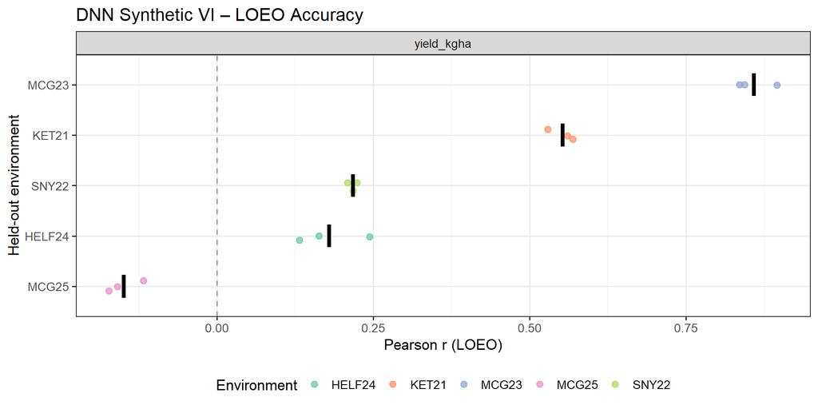

LOEO CV: dots = training repetitions, crossbar = mean r

```r
cv_loeo %>%
  filter(!is.na(r)) %>%
  ggplot(aes(x = r, y = reorder(held_env, r, mean, na.rm = TRUE),
             colour = held_env)) +
  geom_vline(xintercept = 0, linetype = "dashed", colour = "grey60") +
  geom_jitter(height = 0.12, size = 2.5, alpha = 0.7) +
  stat_summary(fun = mean, geom = "crossbar", width = 0.45,
               colour = "black", linewidth = 0.7) +
  facet_wrap(~trait, ncol = 2) +
  scale_colour_brewer(palette = "Set2") +
  labs(x = "Pearson r (LOEO)", y = "Held-out environment",
       title  = "DNN Synthetic VI – LOEO Accuracy",
       colour = "Environment") +
  theme_bw(base_size = 13) +
  theme(legend.position = "bottom")
```

## 7.2 Within-Environment 5-Fold CV (by GID)

```r
wenv_fold_summ <- cv_wenv %>%
  filter(!is.na(r)) %>%
  group_by(trait, Env, fold) %>%
  summarise(r    = mean(r,    na.rm = TRUE),
            rmse = mean(rmse, na.rm = TRUE),
            .groups = "drop")

wenv_env_summary <- wenv_fold_summ %>%
  group_by(trait, Env) %>%
  summarise(mean_r    = mean(r,    na.rm = TRUE),
            sd_r      = sd(r,     na.rm = TRUE),
            mean_rmse = mean(rmse, na.rm = TRUE),
            n_folds   = n(),
            .groups   = "drop")

wenv_summary <- wenv_env_summary %>%
  group_by(trait) %>%
  summarise(mean_r    = mean(mean_r,    na.rm = TRUE),
            sd_r      = mean(sd_r,      na.rm = TRUE),
            mean_rmse = mean(mean_rmse, na.rm = TRUE),
            .groups   = "drop")

wenv_summary %>%
  kable(digits = 3,
        col.names = c("Trait","Mean r","Mean within-env SD r","Mean RMSE"),
        caption   = "Within-environment 5-fold CV (by GID): mean Pearson r across all environments and folds") %>%
  kable_styling(bootstrap_options = c("striped","hover","condensed"),
                full_width = FALSE) %>%
  column_spec(2, bold = TRUE,
              color = ifelse(wenv_summary$mean_r > 0.5, "green", "black"))
```

Within-environment 5-fold CV (by GID): mean Pearson r across all environments and folds

| Trait | Mean r | Mean within-env SD r | Mean RMSE |
| --- | --- | --- | --- |
| yield_kgha | 0.703 | 0.045 | 631.917 |

```r
cat("\nPer-environment within-env CV results:\n")
```

```
##
## Per-environment within-env CV results:
```

```r
wenv_env_summary %>%
  arrange(trait, Env) %>%
  kable(digits = 3,
        col.names = c("Trait","Environment","Mean r","SD r","Mean RMSE","N folds"),
        caption   = "Within-environment 5-fold CV: per-environment summary") %>%
  kable_styling(bootstrap_options = c("striped","hover","condensed"),
                full_width = FALSE)
```

Within-environment 5-fold CV: per-environment summary

| Trait | Environment | Mean r | SD r | Mean RMSE | N folds |
| --- | --- | --- | --- | --- | --- |
| yield_kgha | HELF24 | 0.519 | 0.055 | 682.053 | 5 |
| yield_kgha | KET21 | 0.623 | 0.029 | 674.233 | 5 |
| yield_kgha | MCG23 | 0.900 | 0.018 | 577.781 | 5 |
| yield_kgha | MCG25 | 0.691 | 0.104 | 538.907 | 5 |
| yield_kgha | SNY22 | 0.782 | 0.018 | 686.610 | 5 |

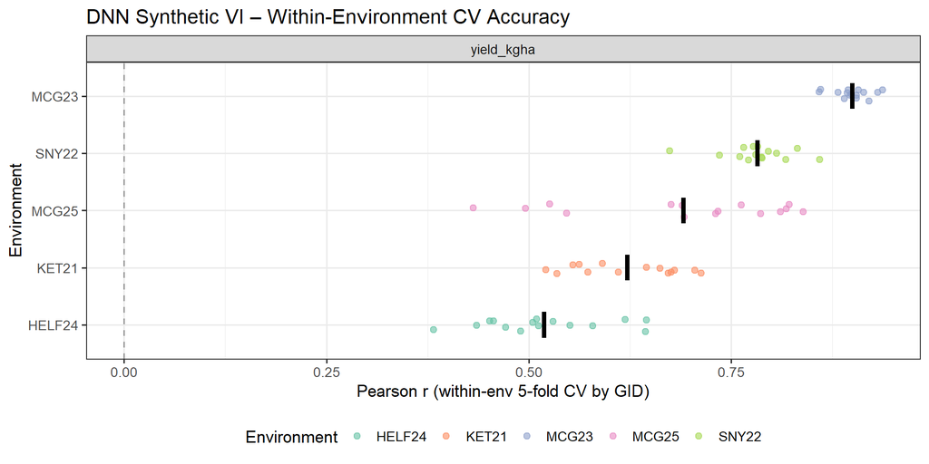

Within-env CV: dots = individual folds × reps, crossbar = mean r per environment

```r
cv_wenv %>%
  filter(!is.na(r)) %>%
  ggplot(aes(x = r, y = reorder(Env, r, mean, na.rm = TRUE),
             colour = Env)) +
  geom_vline(xintercept = 0, linetype = "dashed", colour = "grey60") +
  geom_jitter(height = 0.12, size = 2, alpha = 0.6) +
  stat_summary(fun = mean, geom = "crossbar", width = 0.45,
               colour = "black", linewidth = 0.7) +
  facet_wrap(~trait, ncol = 2) +
  scale_colour_brewer(palette = "Set2") +
  labs(x = "Pearson r (within-env 5-fold CV by GID)", y = "Environment",
       title  = "DNN Synthetic VI – Within-Environment CV Accuracy",
       colour = "Environment") +
  theme_bw(base_size = 13) +
  theme(legend.position = "bottom")
```

## 7.3 CV Scenario Comparison

```r
cv_scenario_tbl <- bind_rows(
  loeo_summary  %>% select(trait, mean_r, sd_r, mean_rmse) %>% mutate(CV = "LOEO"),
  wenv_summary  %>% select(trait, mean_r, sd_r, mean_rmse) %>% mutate(CV = "Within-env 5-fold")
)

cv_scenario_tbl %>%
  arrange(trait, CV) %>%
  kable(digits = 3,
        col.names = c("Trait","Mean r","SD r","Mean RMSE","CV scenario"),
        caption   = "DNN Synthetic VI: LOEO vs. within-environment CV") %>%
  kable_styling(bootstrap_options = c("striped","hover","condensed"),
                full_width = FALSE)
```

DNN Synthetic VI: LOEO vs. within-environment CV

| Trait | Mean r | SD r | Mean RMSE | CV scenario |
| --- | --- | --- | --- | --- |
| yield_kgha | 0.332 | 0.385 | 1040.540 | LOEO |
| yield_kgha | 0.703 | 0.045 | 631.917 | Within-env 5-fold |

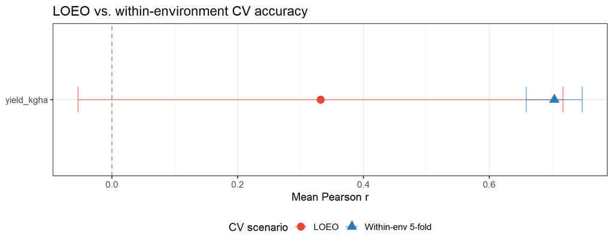

LOEO vs. within-environment CV: mean Pearson r (error bar = SD across folds/envs)

```r
cv_scenario_tbl %>%
  ggplot(aes(x = mean_r,
             y = reorder(trait, mean_r, max, na.rm = TRUE),
             colour = CV, shape = CV)) +
  geom_vline(xintercept = 0, linetype = "dashed", colour = "grey60") +
  geom_errorbarh(aes(xmin = mean_r - sd_r, xmax = mean_r + sd_r),
                 height = 0.2, alpha = 0.6) +
  geom_point(size = 4) +
  scale_colour_manual(values = c(LOEO = "#e34a33",
                                 `Within-env 5-fold` = "#2c7bb6")) +
  labs(x = "Mean Pearson r", y = NULL,
       title  = "LOEO vs. within-environment CV accuracy",
       colour = "CV scenario", shape = "CV scenario") +
  theme_bw(base_size = 13) +
  theme(legend.position = "bottom")
```

# 8 Approach 1 Results: L-BFGS VI Coefficient Optimisation

## 8.1 NDVI Linear Regression (Starting Point)

Standard NDVI with a fixed formula was run under both CV schemes as the starting-point reference — before coefficient optimisation — operating on raw (unscaled) trait values so RMSE is directly comparable.

## 8.2 NDVI — LOEO

```r
if (nrow(ndvi_loeo) > 0) {
  ndvi_loeo_fold <- ndvi_loeo %>%
    filter(!is.na(r)) %>%
    group_by(trait, held_env) %>%
    summarise(r    = mean(r,    na.rm = TRUE),
              rmse = mean(rmse, na.rm = TRUE),
              .groups = "drop")

  ndvi_loeo_summary <- ndvi_loeo_fold %>%
    group_by(trait) %>%
    summarise(ndvi_r    = mean(r,    na.rm = TRUE),
              ndvi_rmse = mean(rmse, na.rm = TRUE),
              .groups = "drop")

  ndvi_loeo_summary %>%
    kable(digits = 3,
          col.names = c("Trait", "NDVI mean r (LOEO)", "NDVI mean RMSE"),
          caption   = "NDVI linear regression — LOEO accuracy") %>%
    kable_styling(bootstrap_options = c("striped","hover","condensed"),
                  full_width = FALSE)
} else {
  cat("NDVI baseline not available.\n")
}
```

NDVI linear regression — LOEO accuracy

| Trait | NDVI mean r (LOEO) | NDVI mean RMSE |
| --- | --- | --- |
| yield_kgha | 0.543 | 1244.086 |

## 8.3 NDVI — Within-Environment 5-Fold CV

```r
if (nrow(ndvi_wenv) > 0) {
  ndvi_wenv_fold <- ndvi_wenv %>%
    filter(!is.na(r)) %>%
    group_by(trait, Env, fold) %>%
    summarise(r    = mean(r,    na.rm = TRUE),
              rmse = mean(rmse, na.rm = TRUE),
              .groups = "drop")

  ndvi_wenv_summary <- ndvi_wenv_fold %>%
    group_by(trait, Env) %>%
    summarise(mean_r    = mean(r,    na.rm = TRUE),
              mean_rmse = mean(rmse, na.rm = TRUE),
              .groups   = "drop") %>%
    group_by(trait) %>%
    summarise(ndvi_r    = mean(mean_r,    na.rm = TRUE),
              ndvi_rmse = mean(mean_rmse, na.rm = TRUE),
              .groups   = "drop")

  ndvi_wenv_summary %>%
    kable(digits = 3,
          col.names = c("Trait", "NDVI mean r (within-env)", "NDVI mean RMSE"),
          caption   = "NDVI linear regression — within-environment 5-fold CV accuracy") %>%
    kable_styling(bootstrap_options = c("striped","hover","condensed"),
                  full_width = FALSE)
} else {
  cat("NDVI baseline not available.\n")
}
```

NDVI linear regression — within-environment 5-fold CV accuracy

| Trait | NDVI mean r (within-env) | NDVI mean RMSE |
| --- | --- | --- |
| yield_kgha | 0.542 | 749.562 |

## 8.4 DNN vs. NDVI — Combined Comparison

```r
if (nrow(ndvi_loeo) > 0 && nrow(ndvi_wenv) > 0) {
  dnn_loeo_r  <- loeo_summary  %>% select(trait, dnn_loeo_r  = mean_r)
  dnn_wenv_r  <- wenv_summary  %>% select(trait, dnn_wenv_r  = mean_r)
  ndvi_loeo_r <- ndvi_loeo_summary %>% select(trait, ndvi_loeo_r = ndvi_r)
  ndvi_wenv_r <- ndvi_wenv_summary %>% select(trait, ndvi_wenv_r = ndvi_r)

  full_comparison <- dnn_loeo_r %>%
    left_join(ndvi_loeo_r, by = "trait") %>%
    left_join(dnn_wenv_r,  by = "trait") %>%
    left_join(ndvi_wenv_r, by = "trait") %>%
    mutate(delta_loeo = dnn_loeo_r - ndvi_loeo_r,
           delta_wenv = dnn_wenv_r - ndvi_wenv_r)

  full_comparison %>%
    arrange(desc(delta_loeo)) %>%
    kable(digits = 3,
          col.names = c("Trait",
                        "DNN r (LOEO)", "NDVI r (LOEO)", "Δr LOEO",
                        "DNN r (within-env)", "NDVI r (within-env)", "Δr within-env"),
          caption = "DNN Synthetic VI vs. NDVI linear regression — both CV scenarios") %>%
    kable_styling(bootstrap_options = c("striped","hover","condensed"),
                  full_width = FALSE) %>%
    column_spec(4, bold = TRUE,
                color = ifelse(full_comparison$delta_loeo > 0, "forestgreen", "firebrick")) %>%
    column_spec(7, bold = TRUE,
                color = ifelse(full_comparison$delta_wenv > 0, "forestgreen", "firebrick"))
}
```

DNN Synthetic VI vs. NDVI linear regression — both CV scenarios

[output not shown]

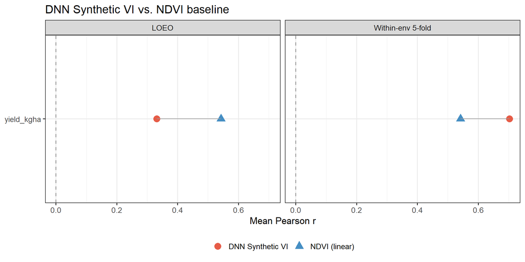

DNN Synthetic VI vs. NDVI linear regression — Pearson r by CV scenario

```r
if (nrow(ndvi_loeo) > 0 && nrow(ndvi_wenv) > 0 && exists("full_comparison")) {
  plot_df <- bind_rows(
    full_comparison %>%
      select(trait, r = dnn_loeo_r)  %>% mutate(model = "DNN Synthetic VI",    CV = "LOEO"),
    full_comparison %>%
      select(trait, r = ndvi_loeo_r) %>% mutate(model = "NDVI (linear)",       CV = "LOEO"),
    full_comparison %>%
      select(trait, r = dnn_wenv_r)  %>% mutate(model = "DNN Synthetic VI",    CV = "Within-env 5-fold"),
    full_comparison %>%
      select(trait, r = ndvi_wenv_r) %>% mutate(model = "NDVI (linear)",       CV = "Within-env 5-fold")
  )

  ggplot(plot_df,
         aes(x = r, y = reorder(trait, r, max, na.rm = TRUE),
             colour = model, shape = model)) +
    geom_vline(xintercept = 0, linetype = "dashed", colour = "grey60") +
    geom_point(size = 4, alpha = 0.9) +
    geom_line(aes(group = interaction(trait, CV)), colour = "grey60",
              linewidth = 0.5) +
    facet_wrap(~CV, ncol = 2) +
    scale_colour_manual(values = c("DNN Synthetic VI" = "#e34a33",
                                   "NDVI (linear)"    = "#3182bd")) +
    scale_shape_manual(values  = c("DNN Synthetic VI" = 16,
                                   "NDVI (linear)"    = 17)) +
    labs(x = "Mean Pearson r", y = NULL,
         title  = "DNN Synthetic VI vs. NDVI baseline",
         colour = NULL, shape = NULL) +
    theme_bw(base_size = 13) +
    theme(legend.position = "bottom")
}
```

## 8.5 Within-Environment Centering: 4-Way Comparison

Compares LOEO accuracy across four modelling strategies: DNN and NDVI linear regression, each run on **uncentered** (per-env z-scored bands) and **within-centered** (env mean subtracted from bands and trait) data.

```r
# Summarise each of the four LOEO variants per environment
summarise_loeo <- function(cv_df, label) {
  cv_df %>%
    filter(!is.na(r)) %>%
    group_by(held_env) %>%
    summarise(r = mean(r, na.rm = TRUE), .groups = "drop") %>%
    mutate(model = label)
}

loeo_4way <- bind_rows(
  summarise_loeo(cv_loeo,           "DNN (z-scored)"),
  summarise_loeo(cv_loeo_centered,  "DNN (centered)"),
  summarise_loeo(ndvi_loeo %>% rename(held_env = held_env),
                 "NDVI linear (uncentered)"),
  summarise_loeo(ndvi_loeo_centered %>% rename(held_env = held_env),
                 "NDVI linear (centered)")
)

loeo_4way_wide <- loeo_4way %>%
  pivot_wider(names_from = model, values_from = r) %>%
  rename(Environment = held_env) %>%
  bind_rows(
    summarise(., across(where(is.numeric), ~ round(mean(., na.rm = TRUE), 3)),
              Environment = "**Mean**")
  ) %>%
  mutate(across(where(is.numeric), ~ round(., 3)))

loeo_4way_wide %>%
  kable(digits = 3,
        caption = "LOEO Pearson r — 4-way comparison: DNN vs. NDVI linear × uncentered vs. within-centered") %>%
  kable_styling(bootstrap_options = c("striped","hover","condensed"),
                full_width = FALSE)
```

LOEO Pearson r — 4-way comparison: DNN vs. NDVI linear × uncentered vs. within-centered

| Environment | DNN (z-scored) | DNN (centered) | NDVI linear (uncentered) | NDVI linear (centered) |
| --- | --- | --- | --- | --- |
| HELF24 | 0.179 | -0.139 | 0.329 | 0.413 |
| KET21 | 0.553 | 0.617 | 0.539 | 0.566 |
| MCG23 | 0.858 | 0.847 | 0.857 | 0.871 |
| MCG25 | -0.149 | NA | 0.671 | NA |
| SNY22 | 0.217 | 0.349 | 0.318 | 0.341 |
| **Mean** | 0.332 | 0.418 | 0.543 | 0.548 |

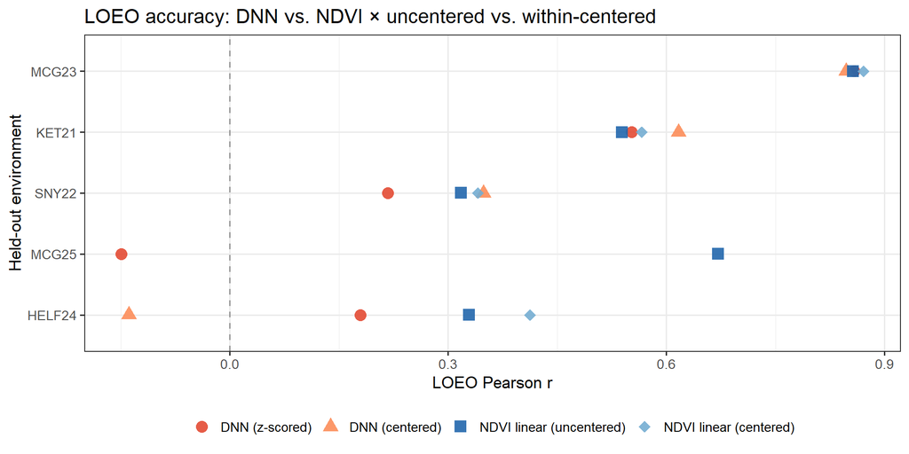

LOEO Pearson r by environment — 4 model variants

```r
loeo_4way %>%
  mutate(model = factor(model,
                        levels = c("DNN (z-scored)", "DNN (centered)",
                                   "NDVI linear (uncentered)", "NDVI linear (centered)"))) %>%
  ggplot(aes(x = r, y = reorder(held_env, r, mean, na.rm = TRUE),
             colour = model, shape = model)) +
  geom_vline(xintercept = 0, linetype = "dashed", colour = "grey60") +
  geom_point(size = 4, alpha = 0.9) +
  scale_colour_manual(values = c("DNN (z-scored)"          = "#e34a33",
                                 "DNN (centered)"           = "#fc8d59",
                                 "NDVI linear (uncentered)" = "#2166ac",
                                 "NDVI linear (centered)"   = "#74add1")) +
  scale_shape_manual(values  = c("DNN (z-scored)"          = 16,
                                 "DNN (centered)"           = 17,
                                 "NDVI linear (uncentered)" = 15,
                                 "NDVI linear (centered)"   = 18)) +
  labs(x = "LOEO Pearson r", y = "Held-out environment",
       title  = "LOEO accuracy: DNN vs. NDVI × uncentered vs. within-centered",
       colour = NULL, shape = NULL) +
  theme_bw(base_size = 13) +
  theme(legend.position = "bottom")
```

## 8.6 L-BFGS Optimised VI Results

L-BFGS optimises the NDVI ratio structure over all 5 bands, extending it beyond the fixed NIR/Red pair. Results below compare the optimised VI against the NDVI starting point under the same two CV designs.

```r
if (nrow(cv_loeo_lbfgs) > 0) {
  lbfgs_loeo_fold <- cv_loeo_lbfgs %>%
    filter(!is.na(r)) %>%
    group_by(trait, held_env) %>%
    summarise(r    = mean(r,    na.rm = TRUE),
              rmse = mean(rmse, na.rm = TRUE),
              n_test = first(n_test), .groups = "drop")

  lbfgs_loeo_summary <- lbfgs_loeo_fold %>%
    group_by(trait) %>%
    summarise(mean_r    = mean(r,    na.rm = TRUE),
              sd_r      = sd(r,     na.rm = TRUE),
              mean_rmse = mean(rmse, na.rm = TRUE),
              .groups = "drop")

  lbfgs_loeo_summary %>%
    kable(digits = 3,
          col.names = c("Trait", "Mean r", "SD r", "Mean RMSE"),
          caption   = "L-BFGS Generalised VI — LOEO accuracy") %>%
    kable_styling(bootstrap_options = c("striped","hover","condensed"),
                  full_width = FALSE)
} else {
  cat("L-BFGS LOEO results not available.\n")
}
```

L-BFGS Generalised VI — LOEO accuracy

| Trait | Mean r | SD r | Mean RMSE |
| --- | --- | --- | --- |
| yield_kgha | 0.461 | 0.305 | 993.255 |

```r
if (nrow(cv_wenv_lbfgs) > 0) {
  lbfgs_wenv_summary <- cv_wenv_lbfgs %>%
    filter(!is.na(r)) %>%
    group_by(trait, Env) %>%
    summarise(r = mean(r, na.rm = TRUE), .groups = "drop") %>%
    group_by(trait) %>%
    summarise(mean_r    = mean(r, na.rm = TRUE),
              sd_r      = sd(r,  na.rm = TRUE),
              .groups = "drop")

  lbfgs_wenv_summary %>%
    kable(digits = 3,
          col.names = c("Trait", "Mean r", "SD r"),
          caption   = "L-BFGS Generalised VI — within-environment 5-fold CV accuracy") %>%
    kable_styling(bootstrap_options = c("striped","hover","condensed"),
                  full_width = FALSE)
} else {
  cat("L-BFGS within-env results not available.\n")
}
```

L-BFGS Generalised VI — within-environment 5-fold CV accuracy

| Trait | Mean r | SD r |
| --- | --- | --- |
| yield_kgha | 0.669 | 0.15 |

```r
if (nrow(cv_loeo_lbfgs) > 0 && nrow(ndvi_loeo) > 0) {
  ndvi_r_loeo  <- ndvi_loeo %>%
    filter(!is.na(r)) %>%
    group_by(trait) %>%
    summarise(ndvi_r = mean(r, na.rm = TRUE), .groups = "drop")

  lbfgs_r_loeo <- cv_loeo_lbfgs %>%
    filter(!is.na(r)) %>%
    group_by(trait) %>%
    summarise(lbfgs_r = mean(r, na.rm = TRUE), .groups = "drop")

  comp_lbfgs <- left_join(ndvi_r_loeo, lbfgs_r_loeo, by = "trait") %>%
    mutate(delta_r = round(lbfgs_r - ndvi_r, 3),
           ndvi_r  = round(ndvi_r,  3),
           lbfgs_r = round(lbfgs_r, 3))

  comp_lbfgs %>%
    kable(digits = 3,
          col.names = c("Trait", "NDVI r (LOEO)", "L-BFGS r (LOEO)", "Δr (L-BFGS − NDVI)"),
          caption   = "L-BFGS coefficient optimisation vs. NDVI linear regression (LOEO)") %>%
    kable_styling(bootstrap_options = c("striped","hover","condensed"),
                  full_width = FALSE) %>%
    column_spec(4, bold = TRUE,
                color = ifelse(comp_lbfgs$delta_r > 0, "forestgreen", "firebrick"))
}
```

L-BFGS coefficient optimisation vs. NDVI linear regression (LOEO)

| Trait | NDVI r (LOEO) | L-BFGS r (LOEO) | Δr (L-BFGS − NDVI) |
| --- | --- | --- | --- |
| yield_kgha | 0.543 | 0.461 | -0.082 |

```r
if (nrow(cv_loeo_lbfgs) > 0 && "formula" %in% names(cv_loeo_lbfgs)) {
  cv_loeo_lbfgs %>%
    select(trait, held_env, r, formula) %>%
    mutate(r = round(r, 3)) %>%
    kable(col.names = c("Trait", "Held-out env", "r", "Optimised VI formula"),
          caption   = "L-BFGS VI — optimised formula per LOEO fold") %>%
    kable_styling(bootstrap_options = c("striped","hover","condensed"),
                  full_width = TRUE, font_size = 9)
}
```

L-BFGS VI — optimised formula per LOEO fold

| Trait | Held-out env | r | Optimised VI formula |
| --- | --- | --- | --- |
| yield_kgha | HELF24 | 0.339 | (-1.5877*blue -1.5877*green -0.8439*red +5.4830*red_edge +0.9809*nir) / (+0.0000*blue +0.0000*green +6884.3987*red +0.0038*red_edge +4160.9414*nir) |
| yield_kgha | KET21 | 0.619 | (-0.9964*blue -0.9964*green -1.0521*red +4.3724*red_edge +1.2285*nir) / (+0.0004*blue +0.0004*green +185.0170*red +0.0374*red_edge +109.5615*nir) |
| yield_kgha | MCG23 | 0.879 | (-2.5639*blue -2.5639*green -1.6307*red +8.5881*red_edge +1.1955*nir) / (+0.0003*blue +0.0003*green +782.5057*red +0.0051*red_edge +406.3301*nir) |
| yield_kgha | MCG25 | 0.069 | (-2.1159*blue -2.1159*green +0.2266*red +8.2792*red_edge +1.2222*nir) / (+0.0001*blue +0.0001*green +2037.8000*red +0.0028*red_edge +1372.5482*nir) |
| yield_kgha | SNY22 | 0.397 | (-0.0167*blue -0.0167*green +0.3513*red +0.1511*red_edge +0.5593*nir) / (+0.0018*blue +0.0018*green +39.3881*red +0.0265*red_edge +38.3551*nir) |

# 9 Transfer Learning: Two-Stage Adaptation CV

Both variants share the same outer structure: **pre-train** the full model on the four non-target environments, then perform K-fold CV **within** the target environment using the pre-trained encoder.

- **Variant B (fine-tune head)**: the encoder is frozen; only the prediction head and environment embeddings are updated on the adaptation (train) GIDs. The target environment’s embedding was never seen during pre-training, so it starts from its random initialisation and is calibrated during fine-tuning.
- **Variant C (SynVI + linear)**: the encoder is completely frozen; the Synthetic VI is extracted for every observation, and a simple OLS (trait ~ SynVI) is fit on the adaptation GIDs and used to predict the test GIDs — no further neural network training.

Both are compared to the standard within-environment 5-fold CV that trains from scratch on each fold.

```r
cat("Running Variant B: freeze encoder, fine-tune head...\n")
```

```
## Running Variant B: freeze encoder, fine-tune head...
```

```r
cv_adapt_finetune <- map_dfr(usable_traits, function(tr) {
  cat("  trait:", tr, "\n")
  res       <- adapt_finetune_cv(model_data_raw, tr, env_levels = env_levels,
                                  n_folds        = 5,   n_reps         = 3,
                                  pretrain_epochs = 300, pretrain_lr    = 3e-3,
                                  finetune_epochs = 50,  finetune_lr    = 1e-3,
                                  batch_size      = 64)
  res$trait <- tr
  res
})
```

```
##   trait: yield_kgha
```

```r
cat("Variant B done. Rows:", nrow(cv_adapt_finetune), "\n")
```

```
## Variant B done. Rows: 75
```

```r
cat("\nRunning Variant C: freeze encoder, linear regression on SynVI...\n")
```

```
##
## Running Variant C: freeze encoder, linear regression on SynVI...
```

```r
cv_adapt_lm <- map_dfr(usable_traits, function(tr) {
  cat("  trait:", tr, "\n")
  res       <- adapt_lm_cv(model_data_raw, tr, env_levels = env_levels,
                            n_folds        = 5,   n_reps      = 3,
                            pretrain_epochs = 300, pretrain_lr = 3e-3,
                            batch_size      = 64)
  res$trait <- tr
  res
})
```

```
##   trait: yield_kgha
```

```r
cat("Variant C done. Rows:", nrow(cv_adapt_lm), "\n")
```

```
## Variant C done. Rows: 75
```

```r
summarise_adapt_env <- function(cv_df, label) {
  cv_df %>%
    filter(!is.na(r)) %>%
    group_by(trait, Env) %>%
    summarise(r = mean(r, na.rm = TRUE), .groups = "drop") %>%
    mutate(model = label)
}

adapt_comparison <- bind_rows(
  cv_wenv %>%
    filter(!is.na(r)) %>%
    group_by(trait, Env) %>%
    summarise(r = mean(r, na.rm = TRUE), .groups = "drop") %>%
    mutate(model = "Within-env (train from scratch)"),
  summarise_adapt_env(cv_adapt_finetune, "Adapt B: fine-tune head"),
  summarise_adapt_env(cv_adapt_lm,       "Adapt C: SynVI + linear")
)

adapt_overall <- adapt_comparison %>%
  group_by(trait, model) %>%
  summarise(mean_r = round(mean(r, na.rm = TRUE), 3),
            sd_r   = round(sd(r,   na.rm = TRUE), 3),
            .groups = "drop") %>%
  arrange(trait, model)

adapt_overall %>%
  kable(digits = 3,
        col.names = c("Trait", "Model", "Mean r", "SD r (across envs)"),
        caption = "Two-stage adaptation CV: mean within-environment Pearson r") %>%
  kable_styling(bootstrap_options = c("striped","hover","condensed"), full_width = FALSE)
```

Two-stage adaptation CV: mean within-environment Pearson r

| Trait | Model | Mean r | SD r (across envs) |
| --- | --- | --- | --- |
| yield_kgha | Adapt B: fine-tune head | 0.336 | 0.390 |
| yield_kgha | Adapt C: SynVI + linear | 0.385 | 0.332 |
| yield_kgha | Within-env (train from scratch) | 0.703 | 0.146 |

```r
cat("\nPer-environment breakdown:\n")
```

```
##
## Per-environment breakdown:
```

```r
adapt_comparison %>%
  pivot_wider(names_from = model, values_from = r) %>%
  mutate(across(where(is.numeric), ~ round(., 3))) %>%
  arrange(trait, Env) %>%
  kable(digits = 3,
        caption = "Pearson r per environment — three within-env CV strategies") %>%
  kable_styling(bootstrap_options = c("striped","hover","condensed"), full_width = FALSE)
```

Pearson r per environment — three within-env CV strategies

| trait | Env | Within-env (train from scratch) | Adapt B: fine-tune head | Adapt C: SynVI + linear |
| --- | --- | --- | --- | --- |
| yield_kgha | HELF24 | 0.519 | 0.140 | 0.084 |
| yield_kgha | KET21 | 0.622 | 0.576 | 0.575 |
| yield_kgha | MCG23 | 0.900 | 0.869 | 0.873 |
| yield_kgha | MCG25 | 0.691 | -0.127 | 0.153 |
| yield_kgha | SNY22 | 0.782 | 0.220 | 0.238 |

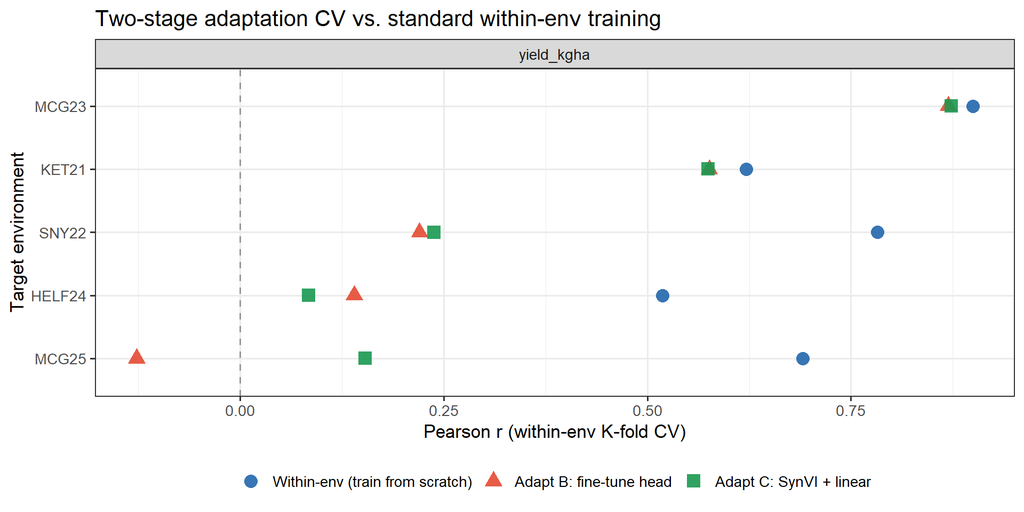

Two-stage adaptation CV vs. standard within-env CV: Pearson r per environment

```r
adapt_comparison %>%
  mutate(model = factor(model,
                        levels = c("Within-env (train from scratch)",
                                   "Adapt B: fine-tune head",
                                   "Adapt C: SynVI + linear"))) %>%
  ggplot(aes(x = r, y = reorder(Env, r, mean, na.rm = TRUE),
             colour = model, shape = model)) +
  geom_vline(xintercept = 0, linetype = "dashed", colour = "grey60") +
  geom_point(size = 4, alpha = 0.9) +
  facet_wrap(~trait, ncol = 2) +
  scale_colour_manual(values = c(
    "Within-env (train from scratch)" = "#2166ac",
    "Adapt B: fine-tune head"         = "#e34a33",
    "Adapt C: SynVI + linear"         = "#1a9850"
  )) +
  scale_shape_manual(values = c(
    "Within-env (train from scratch)" = 16,
    "Adapt B: fine-tune head"         = 17,
    "Adapt C: SynVI + linear"         = 15
  )) +
  labs(x = "Pearson r (within-env K-fold CV)", y = "Target environment",
       title  = "Two-stage adaptation CV vs. standard within-env training",
       colour = NULL, shape = NULL) +
  theme_bw(base_size = 13) +
  theme(legend.position = "bottom")
```

# 10 Full-Data Models and Synthetic VI Extraction

One final model per trait is trained on **all five groups** (no held-out fold). These models are used to (a) extract the Synthetic VI for every observation and (b) derive the VI formula from the learned encoder weights.

```r
full_models <- map(usable_traits, function(trait) {
  cat("Training full model – trait:", trait, "\n")
  tryCatch(
    train_model(model_data, trait, env_levels = env_levels,
                epochs = 300, lr = 3e-3, batch_size = 64, seed = 42L),
    error = function(e) { message(e$message); NULL }
  )
}) %>% set_names(usable_traits)
```

```
## Training full model – trait: yield_kgha
```

```r
synvi_rows <- map_dfr(usable_traits, function(trait) {
  model <- full_models[[trait]]
  if (is.null(model)) return(NULL)
  df <- model_data %>% filter(!is.na(.data[[trait]]))
  bands_t <- torch_tensor(as.matrix(df[, BAND_NAMES, drop = FALSE]),
                          dtype = torch_float())
  with_no_grad({
    vi_vals <- model$get_synthetic_vi(bands_t)$squeeze()$to(device = "cpu")
  })
  df %>%
    select(Env, Timepoint, group) %>%
    mutate(SynVI = as.numeric(vi_vals), trait = trait)
})

cat("Synthetic VI extraction complete. Rows:", nrow(synvi_rows), "\n")
```

```
## Synthetic VI extraction complete. Rows: 1850
```

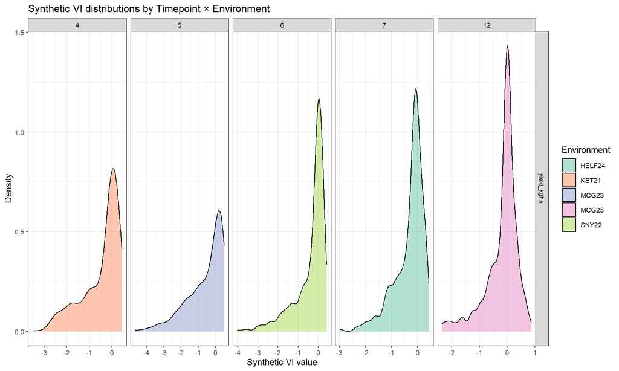

Synthetic VI distributions by Timepoint and Environment, per trait

```r
synvi_rows %>%
  ggplot(aes(x = SynVI, fill = Env)) +
  geom_density(alpha = 0.5) +
  facet_grid(trait ~ Timepoint, scales = "free") +
  scale_fill_brewer(palette = "Set2") +
  labs(x = "Synthetic VI value", y = "Density",
       title = "Synthetic VI distributions by Timepoint × Environment",
       fill  = "Environment") +
  theme_bw(base_size = 10) +
  theme(strip.text.y = element_text(size = 7))
```

# 11 Band Sensitivity Analysis

To interpret *which* raw bands drive each Synthetic VI we compute the gradient of the encoder output with respect to each band input (averaged over all samples).

```r
# Use the full-data models for gradient-based band importance
sensitivity_list <- map_dfr(usable_traits, function(trait) {
  model <- full_models[[trait]]
  if (is.null(model)) return(NULL)
  df <- model_data %>% filter(!is.na(.data[[trait]]))
  bands_t <- torch_tensor(
    as.matrix(df[, BAND_NAMES, drop = FALSE]),
    dtype = torch_float(), requires_grad = TRUE
  )
  vi <- model$encoder(bands_t)
  vi$sum()$backward()
  grads    <- as.matrix(bands_t$grad$to(device = "cpu"))
  abs_mean <- colMeans(abs(grads))
  tibble(trait = trait,
         band  = BAND_NAMES,
         importance = abs_mean / sum(abs_mean))
})

cat("Sensitivity analysis complete.\n")
```

```
## Sensitivity analysis complete.
```

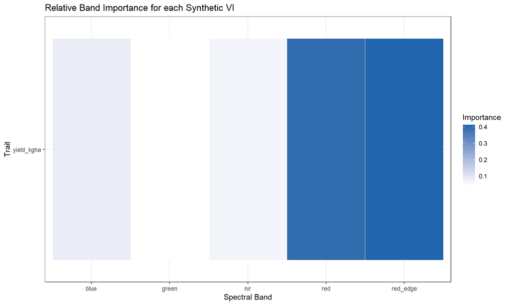

Normalised band importance for each Synthetic VI (gradient-based)

```r
if (!is.null(sensitivity_list) && nrow(sensitivity_list) > 0) {
  imp_wide <- sensitivity_list %>%
    pivot_wider(names_from = band, values_from = importance)

  imp_mat <- as.matrix(imp_wide[, BAND_NAMES])
  rownames(imp_mat) <- imp_wide$trait

    sensitivity_list %>%
      ggplot(aes(x = band, y = reorder(trait, importance),
                 fill = importance)) +
      geom_tile(colour = "white") +
      scale_fill_gradient(low = "white", high = "#2166AC") +
      labs(x = "Spectral Band", y = "Trait",
           fill  = "Importance",
           title = "Relative Band Importance for each Synthetic VI") +
      theme_bw(base_size = 11)
  }
```

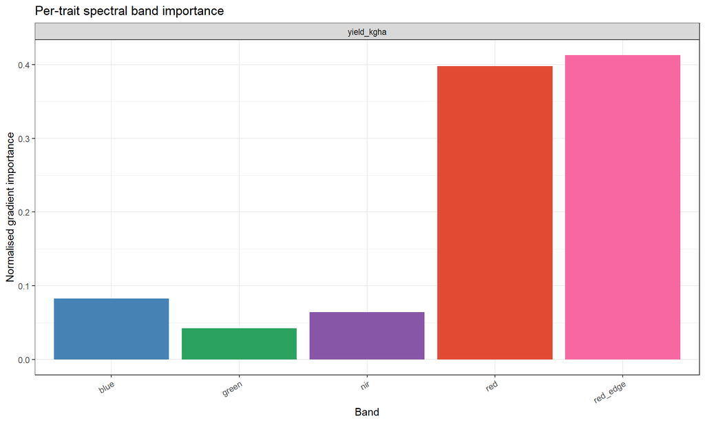

Band importance profiles per trait

```r
if (!is.null(sensitivity_list) && nrow(sensitivity_list) > 0) {
  ggplot(sensitivity_list,
         aes(x = band, y = importance, fill = band)) +
    geom_col() +
    facet_wrap(~trait, ncol = 3) +
    scale_fill_manual(values = c(blue="steelblue", green="#2ca25f",
                                 red="#e34a33", red_edge="#f768a1",
                                 nir="#8856a7")) +
    labs(x = "Band", y = "Normalised gradient importance",
         title = "Per-trait spectral band importance") +
    theme_bw(base_size = 11) +
    theme(axis.text.x  = element_text(angle = 30, hjust = 1),
          legend.position = "none")
}
```

# 12 Synthetic VI Formula

The Synthetic VI is defined by the three learned linear layers of the encoder:

$$\mathbf{h}_1 = \text{ReLU}(\mathbf{W}_1 \mathbf{x} + \mathbf{b}_1),
\quad
\mathbf{h}_2 = \text{ReLU}(\mathbf{W}_2 \mathbf{h}_1 + \mathbf{b}_2),
\quad
\text{SynVI} = \mathbf{w}_3^\top \mathbf{h}_2 + b_3$$

where $\mathbf{x} = [\text{blue, green, red, red\_edge, nir}]^\top$ are the min-max scaled band values. The tables below show the extracted weights for each trait’s full-data model.

```r
for (trait in usable_traits) {
  model <- full_models[[trait]]
  if (is.null(model)) next

  cat("\n\n## Trait:", trait, "\n\n")

  # ── Extract layer weights ──────────────────────────────────────────────
  W1 <- as.matrix(model$encoder$fc1$weight$to(device="cpu")$detach())
  b1 <- as.numeric(model$encoder$fc1$bias$to(device="cpu")$detach())
  W2 <- as.matrix(model$encoder$fc2$weight$to(device="cpu")$detach())
  b2 <- as.numeric(model$encoder$fc2$bias$to(device="cpu")$detach())
  W3 <- as.numeric(model$encoder$fc3$weight$to(device="cpu")$detach())
  b3 <- as.numeric(model$encoder$fc3$bias$to(device="cpu")$detach())

  # W1: shape (16, n_bands)
  colnames(W1) <- BAND_NAMES
  rownames(W1) <- paste0("h1[", seq_len(nrow(W1)), "]")

  cat("**Layer 1 weights** W1 (16 × n_bands) and bias b1:\n\n")
  print(kable(round(cbind(W1, bias = b1), 4), format = "html") %>%
        kable_styling(bootstrap_options = c("striped","condensed"),
                      full_width = FALSE, font_size = 10))

  # W2: shape (8, 16)
  rownames(W2) <- paste0("h2[", seq_len(nrow(W2)), "]")
  colnames(W2) <- paste0("h1[", seq_len(ncol(W2)), "]")

  cat("\n\n**Layer 2 weights** W2 (8 × 16) and bias b2:\n\n")
  print(kable(round(cbind(W2, bias = b2), 4), format = "html") %>%
        kable_styling(bootstrap_options = c("striped","condensed"),
                      full_width = FALSE, font_size = 10))

  # W3: shape (1, 8) → output weights
  w3_df <- tibble(node = paste0("h2[", seq_along(W3), "]"),
                  weight = round(W3, 4))
  cat("\n\n**Layer 3 weights** w3 (1 × 8) and bias b3 =", round(b3, 4), ":\n\n")
  print(kable(w3_df, format = "html",
              col.names = c("Hidden node h2","Output weight")) %>%
        kable_styling(bootstrap_options = c("striped","condensed"),
                      full_width = FALSE, font_size = 10))

  # ── Effective linear sensitivity (first-order Taylor approx) ───────────
  # Compute mean input, propagate through network, get gradient
  df_trait  <- model_data %>% filter(!is.na(.data[[trait]]))
  mean_bands <- colMeans(df_trait[, BAND_NAMES])
  bands_t    <- torch_tensor(matrix(mean_bands, nrow = 1),
                             dtype = torch_float(), requires_grad = TRUE)
  vi_val <- model$encoder(bands_t)
  vi_val$backward()
  sens <- as.numeric(bands_t$grad$to(device="cpu"))
  sens_df <- tibble(Band = BAND_NAMES,
                    `dVI/dBand (at mean)` = round(sens, 4),
                    `|Sensitivity|`       = round(abs(sens), 4)) %>%
    arrange(desc(`|Sensitivity|`))

  cat("\n\n**Linearised sensitivity** (gradient at mean band values):\n\n")
  print(kable(sens_df, format = "html") %>%
        kable_styling(bootstrap_options = c("striped","condensed"),
                      full_width = FALSE))

  # ── Approximate explicit formula (top 3 bands, linear approx) ──────────
  top3 <- sens_df$Band[1:min(3, nrow(sens_df))]
  coef_str <- paste(
    sprintf("%+.4f × %s", sens_df$`dVI/dBand (at mean)`[match(top3, sens_df$Band)], top3),
    collapse = " "
  )
  cat(sprintf(
    "\n\n**Approximate linear formula** (linearised around band means):\n\n$$\\text{SynVI}_{%s} \\approx %.4f %s + \\text{const}$$\n\n",
    trait, 0, coef_str
  ))
}
```

## 12.1 Trait: yield_kgha

**Layer 1 weights** W1 (16 × n_bands) and bias b1:

|  | blue | green | red | red_edge | nir | bias |
| --- | --- | --- | --- | --- | --- | --- |
| h1[1] | 0.2085 | 0.2299 | -0.4982 | 0.7644 | -0.6046 | -0.2388 |
| h1[2] | 0.0000 | 0.0000 | 0.0000 | 0.0000 | 0.0000 | 0.0000 |
| h1[3] | 0.0417 | -0.2354 | -0.4453 | 0.5826 | 0.3587 | 0.0979 |
| h1[4] | 0.0000 | 0.0000 | 0.0000 | 0.0000 | 0.0000 | 0.0000 |
| h1[5] | -0.1496 | -0.0138 | 0.4546 | -0.2290 | -0.3923 | 0.4296 |
| h1[6] | 0.0000 | 0.0000 | 0.0000 | 0.0000 | 0.0000 | -0.0014 |
| h1[7] | 0.0073 | -0.6579 | -0.2558 | 0.7658 | 0.1391 | 0.1035 |
| h1[8] | 0.1873 | -0.0029 | -0.3638 | 0.7614 | 0.1387 | -0.4730 |
| h1[9] | -0.1116 | -0.3386 | -0.4232 | 0.7941 | 0.5397 | -0.1041 |
| h1[10] | -0.4488 | -0.0306 | -0.5604 | 0.8357 | -0.0425 | 0.1367 |
| h1[11] | -0.5060 | -0.2526 | -1.3251 | 0.7116 | 0.1498 | 0.2122 |
| h1[12] | -0.0002 | -0.0002 | -0.0002 | -0.0001 | -0.0002 | -0.0037 |
| h1[13] | 0.1118 | -0.1996 | 0.4652 | -0.8265 | 0.4889 | 0.0641 |
| h1[14] | -0.0373 | 0.3992 | -1.1871 | 0.4199 | -0.3443 | 0.2073 |
| h1[15] | 0.4051 | 0.1819 | 0.6518 | -1.0005 | -0.3090 | -0.0526 |
| h1[16] | -0.0483 | -0.0137 | -0.8412 | 0.8280 | 0.0531 | -0.1119 |

**Layer 2 weights** W2 (8 × 16) and bias b2:

|  | h1[1] | h1[2] | h1[3] | h1[4] | h1[5] | h1[6] | h1[7] | h1[8] | h1[9] | h1[10] | h1[11] | h1[12] | h1[13] | h1[14] | h1[15] | h1[16] | bias |
| --- | --- | --- | --- | --- | --- | --- | --- | --- | --- | --- | --- | --- | --- | --- | --- | --- | --- |
| h2[1] | -0.7599 | 0 | -0.0660 | 0 | 0.1689 | -0.0018 | 0.2786 | 0.8094 | 0.0061 | 0.6431 | 1.0123 | -0.0011 | -0.3571 | 1.0601 | -0.1373 | 0.8720 | 0.0086 |
| h2[2] | 1.1551 | 0 | -0.4633 | 0 | -0.0452 | 0.0000 | -0.8836 | -0.0721 | -0.6326 | -0.5632 | -0.2054 | -0.0005 | -0.0097 | -0.2225 | 0.0756 | -0.1196 | 0.1895 |
| h2[3] | 1.0421 | 0 | -0.1771 | 0 | -0.0688 | 0.0000 | -0.6284 | -0.1997 | -0.4818 | -0.6464 | -0.3366 | 0.0000 | 0.0754 | -0.2459 | 0.3113 | -0.1034 | 0.1524 |
| h2[4] | 1.0819 | 0 | -0.2239 | 0 | 0.2160 | 0.0000 | -0.6294 | 0.0323 | -0.4988 | -0.4476 | -0.2627 | -0.0001 | 0.1487 | -0.1147 | 0.3850 | -0.0388 | 0.0346 |
| h2[5] | 0.0000 | 0 | 0.0000 | 0 | 0.0000 | 0.0000 | 0.0000 | 0.0000 | 0.0000 | 0.0000 | 0.0000 | 0.0000 | 0.0000 | 0.0000 | 0.0000 | 0.0000 | 0.0000 |
| h2[6] | -0.1041 | 0 | 0.2536 | 0 | -0.3570 | -0.0007 | 0.2365 | 0.5574 | 0.3611 | 0.5179 | 0.6494 | -0.0002 | -1.5862 | 0.4070 | -0.5018 | 0.6943 | -0.0881 |
| h2[7] | -0.0340 | 0 | 0.0586 | 0 | -0.0049 | 0.0000 | 0.1579 | 0.1152 | 0.0768 | 0.1773 | 0.1138 | 0.0000 | -0.0212 | 0.1150 | -0.0355 | 0.1230 | 0.0240 |
| h2[8] | -0.5539 | 0 | -0.0173 | 0 | -0.0442 | 0.0005 | 0.1847 | 0.6268 | -0.0640 | 0.4944 | 1.0501 | -0.0015 | -0.7018 | 1.0187 | -0.7531 | 0.8060 | 0.0818 |

**Layer 3 weights** w3 (1 × 8) and bias b3 = 0.0572 :

| Hidden node h2 | Output weight |
| --- | --- |
| h2[1] | -0.9879 |
| h2[2] | 0.7343 |
| h2[3] | 0.5265 |
| h2[4] | 0.4763 |
| h2[5] | 0.0003 |
| h2[6] | -1.1540 |
| h2[7] | -0.0773 |
| h2[8] | -1.0272 |

**Linearised sensitivity** (gradient at mean band values):

| Band | dVI/dBand (at mean) | \|Sensitivity\| |
| --- | --- | --- |
| red_edge | -2.1050 | 2.1050 |
| red | 1.1579 | 1.1579 |
| blue | 0.6513 | 0.6513 |
| nir | 0.6132 | 0.6132 |
| green | 0.0998 | 0.0998 |

**Approximate linear formula** (linearised around band means):

$$\text{SynVI}_{yield_kgha} \approx 0.0000
-2.1050 × red_edge +1.1579 × red +0.6513 × blue +
\text{const}$$

# 13 Comparison: Synthetic VI vs. Standard VIs

For each standard VI and trait the same LOGO scheme is used (train on 4 groups, test on 5th) with a simple linear regression baseline.

```r
# LOGO linear regression benchmark for each standard VI × trait
linreg_logo_cv <- function(data, vi, trait) {
  map_dfr(group_levels_all, function(held_out) {
    tr <- data %>% filter(group != held_out,
                          !is.na(.data[[vi]]), !is.na(.data[[trait]]))
    te <- data %>% filter(group == held_out,
                          !is.na(.data[[vi]]), !is.na(.data[[trait]]))
    if (nrow(tr) < 10 || nrow(te) < 2) return(NULL)
    fit  <- lm(as.formula(paste(trait, "~", vi)), data = tr)
    pred <- predict(fit, newdata = te)
    tibble(held_out = held_out,
           r = cor(pred, te[[trait]], use = "complete.obs"))
  }) %>%
  summarise(mean_r = mean(r, na.rm = TRUE)) %>%
  pull(mean_r)
}

if (length(vi_cols) > 0) {
  cat("Computing standard VI baselines for", length(vi_cols), "VIs ×",
      length(usable_traits), "traits ...\n")
  std_vi_results <- expand_grid(vi = vi_cols, trait = usable_traits) %>%
    mutate(mean_r = map2_dbl(vi, trait,
                             ~linreg_logo_cv(model_data, .x, .y)))

  best_std_vi <- std_vi_results %>%
    group_by(trait) %>%
    slice_max(mean_r, n = 1, with_ties = FALSE) %>%
    ungroup() %>%
    rename(best_vi = vi, std_r = mean_r)

  comparison <- loeo_summary %>%
    select(trait, syn_r = mean_r) %>%
    left_join(best_std_vi, by = "trait") %>%
    mutate(improvement = syn_r - std_r)

  comparison %>%
    arrange(desc(improvement)) %>%
    kable(digits = 3,
          col.names = c("Trait","DNN Synthetic VI r","Best std VI","Std VI r","Δr"),
          caption = "DNN Synthetic VI vs. best standard VI (LOEO mean Pearson r)") %>%
    kable_styling(bootstrap_options = c("striped","hover","condensed"),
                  full_width = FALSE) %>%
    column_spec(5,
                bold  = TRUE,
                color = ifelse(comparison$improvement > 0, "green", "red"))
}
```

```
## Computing standard VI baselines for 10 VIs × 1 traits ...
```

DNN Synthetic VI vs. best standard VI (LOEO mean Pearson r)

| Trait | DNN Synthetic VI r | Best std VI | Std VI r | Δr |
| --- | --- | --- | --- | --- |
| yield_kgha | 0.332 | SAVI | 0.583 | -0.252 |

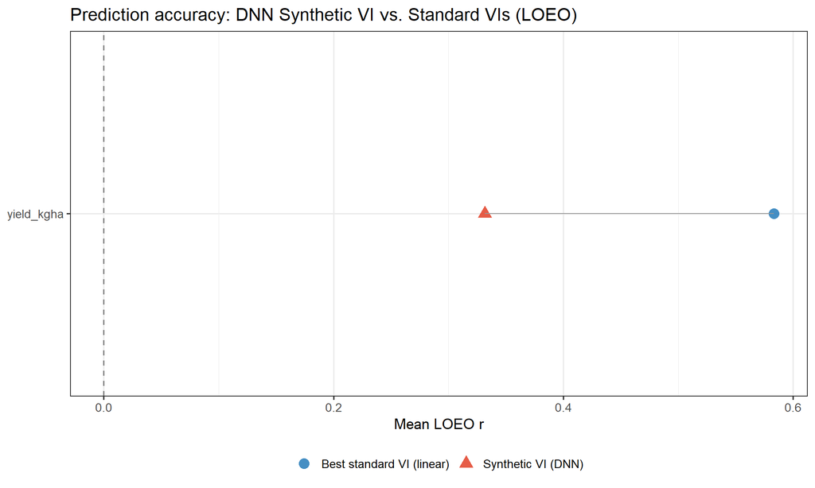

Prediction accuracy: Synthetic VI vs. best standard VI

```r
if (length(vi_cols) > 0 && exists("comparison")) {
  comparison %>%
    pivot_longer(c(syn_r, std_r),
                 names_to = "type", values_to = "r") %>%
    mutate(type = recode(type, syn_r = "Synthetic VI (DNN)",
                               std_r = "Best standard VI (linear)"),
           trait = reorder(trait, ifelse(type == "Synthetic VI (DNN)", r, NA),
                           mean, na.rm = TRUE)) %>%
    ggplot(aes(x = r, y = trait, colour = type, shape = type)) +
    geom_vline(xintercept = 0, linetype = "dashed", colour = "grey50") +
    geom_point(size = 4, alpha = 0.9) +
    geom_line(aes(group = trait), colour = "grey60", linewidth = 0.5) +
    scale_colour_manual(values = c("Synthetic VI (DNN)"    = "#e34a33",
                                   "Best standard VI (linear)" = "#3182bd")) +
    labs(x = "Mean LOEO r", y = NULL,
         title  = "Prediction accuracy: DNN Synthetic VI vs. Standard VIs (LOEO)",
         colour = NULL, shape = NULL) +
    theme_bw(base_size = 13) +
    theme(legend.position = "bottom")
}
```

# 14 Synthetic VI Correlations with Standard VIs

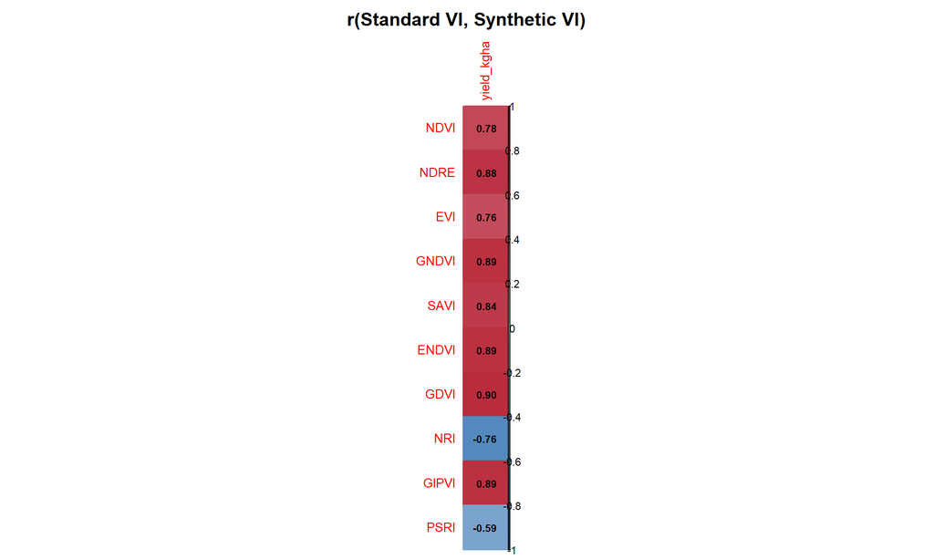

Correlation between Synthetic VIs (per-trait) and standard VIs

```r
if (length(vi_cols) > 0 && nrow(synvi_rows) > 0) {
  # Join synthetic VI values back to model_data for standard VI columns
  synvi_wide <- synvi_rows %>%
    select(Env, Timepoint, group, trait, SynVI) %>%
    pivot_wider(names_from = trait, values_from = SynVI,
                names_prefix = "SynVI_",
                values_fn = mean)   # average if >1 row per cell

  stdvi_sub <- model_data %>%
    select(Env, Timepoint, group, all_of(vi_cols)) %>%
    group_by(Env, Timepoint, group) %>%
    summarise(across(all_of(vi_cols), mean, na.rm = TRUE), .groups = "drop")

  joined <- left_join(synvi_wide, stdvi_sub, by = c("Env","Timepoint","group"))

  synvi_trait_cols <- names(joined)[startsWith(names(joined), "SynVI_")]
  if (length(synvi_trait_cols) > 0 && length(vi_cols) > 0) {
    cor_mat  <- cor(joined[, c(vi_cols, synvi_trait_cols)],
                    use = "pairwise.complete.obs")
    sub_cor  <- cor_mat[vi_cols, synvi_trait_cols, drop = FALSE]
    colnames(sub_cor) <- str_remove(colnames(sub_cor), "SynVI_")
    corrplot(sub_cor, method = "color",
             col  = colorRampPalette(c("#2166AC","white","#B2182B"))(200),
             tl.cex = 0.8, cl.cex = 0.7,
             addCoef.col = "black", number.cex = 0.65,
             title = "r(Standard VI, Synthetic VI)", mar = c(0,0,2,0))
  }
}
```

# 15 All-Model Comparison

Side-by-side comparison of all three approaches under the same LOEO and within-environment 5-fold CV designs.

**Approach 1 — L-BFGS Coefficient Optimisation**

- **NDVI (linear)** — fixed NIR/Red ratio, linear regression (baseline before optimisation)
- **L-BFGS VI** — NDVI structure extended to all 5 bands with L-BFGS-optimised coefficients

**Approach 2 — Symbolic Regression**

- **LASSO poly SR** — LASSO on degree-2 polynomial of all 5 bands (optimised coefficients, fixed polynomial structure)
- **PySR** — genetic programming over symbolic expressions (optimises both structure and coefficients; requires Python+PySR)

**Approach 3 — Supervised DNN with Feature Extraction**

- **DNN bottleneck (SynVI)** — Synthetic VI model (5 → 16 → 8 → 1 bottleneck + env embedding)
- **DNN no-bottleneck** — full DNN (5 → 16 → 8 ‖ env embed → 8 → 1) upper-bound reference

```r
# ── LOEO: aggregate each model to mean r per trait ────────────────────────
agg_loeo <- function(cv_df, model_label) {
  cv_df %>%
    filter(!is.na(r)) %>%
    group_by(trait) %>%
    summarise(r = mean(r, na.rm = TRUE), .groups = "drop") %>%
    mutate(model = model_label)
}

loeo_all <- bind_rows(
  ndvi_loeo %>%
    filter(!is.na(r)) %>%
    group_by(trait) %>% summarise(r = mean(r, na.rm = TRUE), .groups = "drop") %>%
    mutate(model = "NDVI (linear)"),
  if (nrow(cv_loeo_lbfgs) > 0) agg_loeo(cv_loeo_lbfgs, "L-BFGS VI") else NULL,
  agg_loeo(cv_loeo_lasso,   "LASSO poly SR"),
  agg_loeo(cv_loeo,         "DNN bottleneck (SynVI)"),
  agg_loeo(cv_loeo_fulldnn, "DNN no-bottleneck")
)

if (nrow(cv_loeo_pysr) > 0)
  loeo_all <- bind_rows(loeo_all, agg_loeo(cv_loeo_pysr, "PySR"))

loeo_all_wide <- loeo_all %>%
  pivot_wider(names_from = model, values_from = r) %>%
  mutate(across(where(is.numeric), ~ round(., 3)))

loeo_all_wide %>%
  kable(digits = 3,
        caption = "LOEO mean Pearson r — all modelling approaches") %>%
  kable_styling(bootstrap_options = c("striped","hover","condensed"),
                full_width = FALSE)
```

LOEO mean Pearson r — all modelling approaches

| trait | NDVI (linear) | L-BFGS VI | LASSO poly SR | DNN bottleneck (SynVI) | DNN no-bottleneck |
| --- | --- | --- | --- | --- | --- |
| yield_kgha | 0.543 | 0.461 | 0.381 | 0.332 | 0.39 |

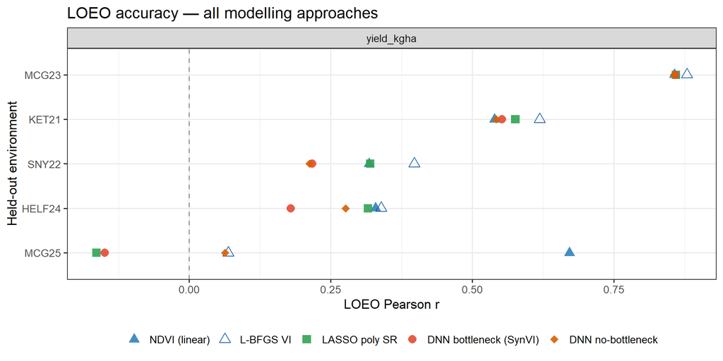

LOEO Pearson r: all modelling approaches per held-out environment

```r
loeo_per_env <- bind_rows(
  ndvi_loeo %>%
    filter(!is.na(r)) %>%
    group_by(trait, held_env) %>% summarise(r = mean(r, na.rm = TRUE), .groups = "drop") %>%
    mutate(model = "NDVI (linear)"),
  if (nrow(cv_loeo_lbfgs) > 0)
    cv_loeo_lbfgs %>%
      filter(!is.na(r)) %>%
      group_by(trait, held_env) %>% summarise(r = mean(r, na.rm = TRUE), .groups = "drop") %>%
      mutate(model = "L-BFGS VI")
  else NULL,
  cv_loeo_lasso %>%
    filter(!is.na(r)) %>%
    group_by(trait, held_env) %>% summarise(r = mean(r, na.rm = TRUE), .groups = "drop") %>%
    mutate(model = "LASSO poly SR"),
  cv_loeo %>%
    filter(!is.na(r)) %>%
    group_by(trait, held_env) %>% summarise(r = mean(r, na.rm = TRUE), .groups = "drop") %>%
    mutate(model = "DNN bottleneck (SynVI)"),
  cv_loeo_fulldnn %>%
    filter(!is.na(r)) %>%
    group_by(trait, held_env) %>% summarise(r = mean(r, na.rm = TRUE), .groups = "drop") %>%
    mutate(model = "DNN no-bottleneck")
)
if (nrow(cv_loeo_pysr) > 0)
  loeo_per_env <- bind_rows(
    loeo_per_env,
    cv_loeo_pysr %>%
      filter(!is.na(r)) %>%
      group_by(trait, held_env) %>% summarise(r = mean(r, na.rm = TRUE), .groups = "drop") %>%
      mutate(model = "PySR")
  )

model_colours <- c(
  "NDVI (linear)"          = "#3182bd",
  "L-BFGS VI"              = "#08519c",
  "LASSO poly SR"          = "#31a354",
  "PySR"                   = "#006d2c",
  "DNN bottleneck (SynVI)" = "#e34a33",
  "DNN no-bottleneck"      = "#d95f02"
)
model_shapes <- c(
  "NDVI (linear)"          = 17,
  "L-BFGS VI"              = 2,
  "LASSO poly SR"          = 15,
  "PySR"                   = 8,
  "DNN bottleneck (SynVI)" = 16,
  "DNN no-bottleneck"      = 18
)

loeo_per_env %>%
  mutate(model = factor(model, levels = names(model_colours))) %>%
  ggplot(aes(x = r, y = reorder(held_env, r, mean, na.rm = TRUE),
             colour = model, shape = model)) +
  geom_vline(xintercept = 0, linetype = "dashed", colour = "grey60") +
  geom_point(size = 3.5, alpha = 0.9) +
  facet_wrap(~trait, ncol = 2) +
  scale_colour_manual(values = model_colours) +
  scale_shape_manual(values  = model_shapes) +
  labs(x = "LOEO Pearson r", y = "Held-out environment",
       title  = "LOEO accuracy — all modelling approaches",
       colour = NULL, shape = NULL) +
  theme_bw(base_size = 13) +
  theme(legend.position = "bottom")
```

```r
agg_wenv <- function(cv_df, model_label) {
  cv_df %>%
    filter(!is.na(r)) %>%
    group_by(trait) %>%
    summarise(r = mean(r, na.rm = TRUE), .groups = "drop") %>%
    mutate(model = model_label)
}

wenv_all <- bind_rows(
  ndvi_wenv %>%
    filter(!is.na(r)) %>%
    group_by(trait) %>% summarise(r = mean(r, na.rm = TRUE), .groups = "drop") %>%
    mutate(model = "NDVI (linear)"),
  if (nrow(cv_wenv_lbfgs) > 0) agg_wenv(cv_wenv_lbfgs, "L-BFGS VI") else NULL,
  agg_wenv(cv_wenv_lasso,   "LASSO poly SR"),
  agg_wenv(cv_wenv,         "DNN bottleneck (SynVI)"),
  agg_wenv(cv_wenv_fulldnn, "DNN no-bottleneck")
)
if (nrow(cv_wenv_pysr) > 0)
  wenv_all <- bind_rows(wenv_all, agg_wenv(cv_wenv_pysr, "PySR"))

wenv_all %>%
  pivot_wider(names_from = model, values_from = r) %>%
  mutate(across(where(is.numeric), ~ round(., 3))) %>%
  kable(digits = 3,
        caption = "Within-env 5-fold CV mean Pearson r — all modelling approaches") %>%
  kable_styling(bootstrap_options = c("striped","hover","condensed"),
                full_width = FALSE)
```

Within-env 5-fold CV mean Pearson r — all modelling approaches

| trait | NDVI (linear) | L-BFGS VI | LASSO poly SR | DNN bottleneck (SynVI) | DNN no-bottleneck |
| --- | --- | --- | --- | --- | --- |
| yield_kgha | 0.542 | 0.669 | 0.713 | 0.704 | 0.701 |

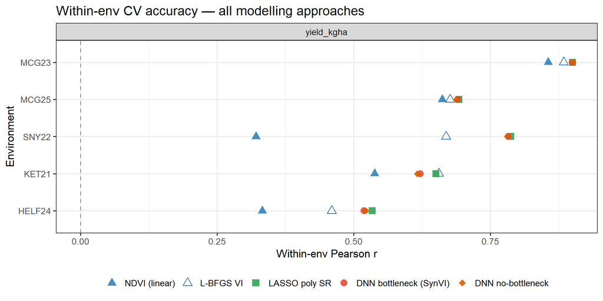

Within-env CV Pearson r: all modelling approaches

```r
wenv_per_env <- bind_rows(
  ndvi_wenv %>%
    filter(!is.na(r)) %>%
    group_by(trait, Env) %>% summarise(r = mean(r, na.rm = TRUE), .groups = "drop") %>%
    mutate(model = "NDVI (linear)"),
  if (nrow(cv_wenv_lbfgs) > 0)
    cv_wenv_lbfgs %>%
      filter(!is.na(r)) %>%
      group_by(trait, Env) %>% summarise(r = mean(r, na.rm = TRUE), .groups = "drop") %>%
      mutate(model = "L-BFGS VI")
  else NULL,
  cv_wenv_lasso %>%
    filter(!is.na(r)) %>%
    group_by(trait, Env) %>% summarise(r = mean(r, na.rm = TRUE), .groups = "drop") %>%
    mutate(model = "LASSO poly SR"),
  cv_wenv %>%
    filter(!is.na(r)) %>%
    group_by(trait, Env) %>% summarise(r = mean(r, na.rm = TRUE), .groups = "drop") %>%
    mutate(model = "DNN bottleneck (SynVI)"),
  cv_wenv_fulldnn %>%
    filter(!is.na(r)) %>%
    group_by(trait, Env) %>% summarise(r = mean(r, na.rm = TRUE), .groups = "drop") %>%
    mutate(model = "DNN no-bottleneck")
)
if (nrow(cv_wenv_pysr) > 0)
  wenv_per_env <- bind_rows(
    wenv_per_env,
    cv_wenv_pysr %>%
      filter(!is.na(r)) %>%
      group_by(trait, Env) %>% summarise(r = mean(r, na.rm = TRUE), .groups = "drop") %>%
      mutate(model = "PySR")
  )

wenv_per_env %>%
  mutate(model = factor(model, levels = names(model_colours))) %>%
  ggplot(aes(x = r, y = reorder(Env, r, mean, na.rm = TRUE),
             colour = model, shape = model)) +
  geom_vline(xintercept = 0, linetype = "dashed", colour = "grey60") +
  geom_point(size = 3.5, alpha = 0.9) +
  facet_wrap(~trait, ncol = 2) +
  scale_colour_manual(values = model_colours) +
  scale_shape_manual(values  = model_shapes) +
  labs(x = "Within-env Pearson r", y = "Environment",
       title  = "Within-env CV accuracy — all modelling approaches",
       colour = NULL, shape = NULL) +
  theme_bw(base_size = 13) +
  theme(legend.position = "bottom")
```

```r
# ── Display the LASSO polynomial formula per held-out environment ──────────
if (nrow(cv_loeo_lasso) > 0 && "formula" %in% names(cv_loeo_lasso)) {
  cv_loeo_lasso %>%
    select(trait, held_env, r, n_terms, formula) %>%
    mutate(r = round(r, 3)) %>%
    kable(col.names = c("Trait","Held-out env","r","Active terms","LASSO formula"),
          caption   = "LASSO polynomial SR — selected formula per LOEO fold") %>%
    kable_styling(bootstrap_options = c("striped","hover","condensed"),
                  full_width = TRUE, font_size = 9)
}
```

LASSO polynomial SR — selected formula per LOEO fold

| Trait | Held-out env | r | Active terms | LASSO formula |
| --- | --- | --- | --- | --- |
| yield_kgha | HELF24 | 0.315 | 19 | +1.2629*(Intercept) +2.8920*blue -6.6781*red +0.1830*red_edge -2.6753*nir -5.9181*blue_sq -4.0803*green_sq +7.7489*red_sq -17.3743*red_edge_sq +1.1340*nir_sq +0.0003*bluexgreen -16.1338*bluexred +21.6… |
| yield_kgha | KET21 | 0.576 | 19 | +1.9146*(Intercept) +1.1438*blue +0.4701*green -5.5867*red -1.4752*red_edge -3.6530*nir -9.3512*blue_sq -0.0000*green_sq +3.2858*red_sq -13.3134*red_edge_sq +0.2330*nir_sq -0.0022*bluexgreen -0.0651*b… |
| yield_kgha | MCG23 | 0.860 | 18 | +1.0002*(Intercept) +3.9963*blue +1.5207*green -5.3694*red -5.8040*red_edge -0.9000*blue_sq -0.0000*green_sq +5.4151*red_sq -10.9146*red_edge_sq -3.0006*nir_sq -19.8921*bluexred +3.7585*bluexred_edge … |
| yield_kgha | MCG25 | -0.164 | 17 | +1.8585*(Intercept) -0.1330*blue -0.0759*green -6.7994*red +5.0388*red_edge -5.7830*nir -13.3351*blue_sq +2.7508*red_sq -10.9890*red_edge_sq +0.9506*nir_sq -0.2018*bluexgreen +13.6597*bluexred_edge +6… |
| yield_kgha | SNY22 | 0.320 | 15 | +1.4646*(Intercept) -5.9098*red +1.2757*red_edge -4.0340*nir -4.8824*blue_sq +1.1759*red_sq -6.5793*red_edge_sq +1.8598*nir_sq -0.4326*bluexred +0.2053*bluexred_edge +12.4954*bluexnir -4.8220*greenxre… |

```r
# ── Display the PySR-discovered formula per held-out environment ───────────
if (nrow(cv_loeo_pysr) > 0 && "formula" %in% names(cv_loeo_pysr)) {
  cv_loeo_pysr %>%
    select(trait, held_env, r, formula) %>%
    mutate(r = round(r, 3)) %>%
    kable(col.names = c("Trait","Held-out env","r","PySR formula"),
          caption   = "PySR symbolic regression — discovered formula per LOEO fold") %>%
    kable_styling(bootstrap_options = c("striped","hover","condensed"),
                  full_width = TRUE, font_size = 9)
} else {
  cat("PySR results not available (Python/PySR not installed).\n")
  cat("To enable: reticulate::install_python(); reticulate::py_install('pysr')\n")
}
```

```
## PySR results not available (Python/PySR not installed).
## To enable: reticulate::install_python(); reticulate::py_install('pysr')
```

# 16 Summary

```r
final_summary <- loeo_summary %>%
  left_join(
    wenv_summary %>% select(trait, wenv_r = mean_r),
    by = "trait"
  ) %>%
  left_join(
    sensitivity_list %>%
      group_by(trait) %>%
      slice_max(importance, n = 1, with_ties = FALSE) %>%
      select(trait, top_band = band),
    by = "trait"
  ) %>%
  arrange(desc(mean_r))

final_summary %>%
  kable(digits = 3,
        col.names = c("Trait","LOEO r","SD r","LOEO RMSE","N folds",
                      "Within-env r","Top band"),
        caption = "Summary: DNN Synthetic VI – LOEO and within-environment CV accuracy with dominant spectral band") %>%
  kable_styling(bootstrap_options = c("striped","hover","condensed"),
                full_width = FALSE)
```

Summary: DNN Synthetic VI – LOEO and within-environment CV accuracy with dominant spectral band

| Trait | LOEO r | SD r | LOEO RMSE | N folds | Within-env r | Top band |
| --- | --- | --- | --- | --- | --- | --- |
| yield_kgha | 0.332 | 0.385 | 1040.54 | 5 | 0.703 | red_edge |